# Final Project: Ten-Minute Analytics Challenge

```python
df_elsalvador_covid_filtered_level3.BPS5h.unique()
```

```
array([nan, 'Other (Specify)',
       'Change targeting health products or services'], dtype=object)
```

```python
df_elsalvador_covid_filtered_level3.BPS5h1x.unique()
```

```
array([nan, 'Hygiene protocols, and sanitation', 'Schedule changes',
       'Only digytal mode to sell',
       'essential products and personal protection', 'Delivery service',
       'production of protective screens',
       'INCREASED THE INVENTORY OF PRODUCTS DEMANDED BY THE PANDEMIC LIKE ALCOHOL GEL, MASKS AND OTHERS',
       'Air conditioner sales', 'necessitynitty-grittymustfundamentals',
       'Invested more in sanitation products'], dtype=object)
```

return the numerical value corresponding to the Ordered Category  
For the relevant columns

```python
df_elsalvador_covid_filtered_level3['estbl_status'] = df_elsalvador_covid_filtered_level3['COVb0'].apply(get_numerical_val_4)
df_elsalvador_covid_filtered_level3['is_estbl_closed_temp'] = df_elsalvador_covid_filtered_level3['COVb1a'].apply(get_numerical_val_3)
df_elsalvador_covid_filtered_level3['no_weeks_estbl_closed'] = df_elsalvador_covid_filtered_level3['COVb1b'].apply(get_numerical_val_2)
df_elsalvador_covid_filtered_level3['is_sales_changed'] = df_elsalvador_covid_filtered_level3['COVb2a'].apply(get_numerical_val_4)
df_elsalvador_covid_filtered_level3['pct_sales_incr'] = df_elsalvador_covid_filtered_level3['COVb2b'].apply(get_numerical_val_2)
df_elsalvador_covid_filtered_level3['pct_sales_decr'] = df_elsalvador_covid_filtered_level3['COVb2c'].apply(get_numerical_val_2)
df_elsalvador_covid_filtered_level3['pct_sales_national'] = df_elsalvador_covid_filtered_level3['COVb3a'].apply(get_numerical_val_2)
df_elsalvador_covid_filtered_level3['pct_sales_indirect_exports'] = df_elsalvador_covid_filtered_level3['COVb3b'].apply(get_numerical_val_2)
df_elsalvador_covid_filtered_level3['pct_sales_direct_exports'] = df_elsalvador_covid_filtered_level3['COVb3c'].apply(get_numerical_val_2)
df_elsalvador_covid_filtered_level3['pct_dir_indir_exports_status'] = df_elsalvador_covid_filtered_level3['COVb4'].apply(get_numerical_val_4)
df_elsalvador_covid_filtered_level3['is_estbl_adjusted'] = df_elsalvador_covid_filtered_level3['COVc3'].apply(get_numerical_val_3)
df_elsalvador_covid_filtered_level3['estbl_total_work_hrs_status'] = df_elsalvador_covid_filtered_level3['COVc2a'].apply(get_numerical_val_4)
df_elsalvador_covid_filtered_level3['estbl_demand_status'] = df_elsalvador_covid_filtered_level3['COVc2b'].apply(get_numerical_val_4)
df_elsalvador_covid_filtered_level3['estbl_supply_inputs_status'] = df_elsalvador_covid_filtered_level3['COVc2c'].apply(get_numerical_val_4)
df_elsalvador_covid_filtered_level3['is_biz_actvty_online'] = df_elsalvador_covid_filtered_level3['COVc4a'].apply(get_numerical_val_3)
df_elsalvador_covid_filtered_level3['is_delivery_goods_svc'] = df_elsalvador_covid_filtered_level3['COVc4b'].apply(get_numerical_val_3)
df_elsalvador_covid_filtered_level3['is_remote_work_agmt'] = df_elsalvador_covid_filtered_level3['COVc4c'].apply(get_numerical_val_3)
df_elsalvador_covid_filtered_level3['is_digital_platforms_biz_admin'] = df_elsalvador_covid_filtered_level3['BPS5a_01'].apply(get_numerical_val_3)
df_elsalvador_covid_filtered_level3['is_digital_platforms_supply_chn_mgmt'] = df_elsalvador_covid_filtered_level3['BPS5a_03'].apply(get_numerical_val_3)
df_elsalvador_covid_filtered_level3['is_digital_platforms_mktg'] = df_elsalvador_covid_filtered_level3['BPS5a_04'].apply(get_numerical_val_3)
df_elsalvador_covid_filtered_level3['is_digital_platforms_sale'] = df_elsalvador_covid_filtered_level3['BPS5a_05'].apply(get_numerical_val_3)
df_elsalvador_covid_filtered_level3['is_digital_platforms_paymt_meth'] = df_elsalvador_covid_filtered_level3['BPS5a_06'].apply(get_numerical_val_3)
df_elsalvador_covid_filtered_level3['is_digital_platforms_svc_dvy'] = df_elsalvador_covid_filtered_level3['BPS5a_07'].apply(get_numerical_val_3)
df_elsalvador_covid_filtered_level3['pct_workforce_remote'] = df_elsalvador_covid_filtered_level3['COVc6'].apply(get_numerical_val_2)
df_elsalvador_covid_filtered_level3['pct_online_sales'] = df_elsalvador_covid_filtered_level3['COVc5'].apply(get_numerical_val_2)
df_elsalvador_covid_filtered_level3['pct_share_digi_pltms_web_sales'] = df_elsalvador_covid_filtered_level3['BPS5b'].apply(get_numerical_val_2)
df_elsalvador_covid_filtered_level3['is_estbl_invested_digi_sol'] = df_elsalvador_covid_filtered_level3['BPS5d'].apply(get_numerical_val_3)
```

Unit-testing to check the result of above statements

```python
df_elsalvador_covid_filtered_level3[['COVb0','estbl_status','COVb1a','is_estbl_closed_temp','COVb1b','no_weeks_estbl_closed','COVb2a','is_sales_changed','COVb2b','pct_sales_incr','COVb2c','pct_sales_decr',
                                    'COVb3a','pct_sales_national','COVb3b','pct_sales_indirect_exports','COVb3c','pct_sales_direct_exports',
                                    'COVb4','pct_dir_indir_exports_status','COVc3','is_estbl_adjusted',
                                    'COVc2a','estbl_total_work_hrs_status','COVc2b','estbl_demand_status','COVc2c','estbl_supply_inputs_status',
                                    'COVc4a','is_biz_actvty_online','COVc4b','is_delivery_goods_svc','COVc4c','is_remote_work_agmt',
                                    'BPS5a_01','is_digital_platforms_biz_admin','BPS5a_03','is_digital_platforms_supply_chn_mgmt','BPS5a_04','is_digital_platforms_mktg',
                                    'BPS5a_05','is_digital_platforms_sale','BPS5a_06','is_digital_platforms_paymt_meth','BPS5a_07','is_digital_platforms_svc_dvy',
                                    'COVc6','pct_workforce_remote','COVc5','pct_online_sales',
                                    'BPS5b','pct_share_digi_pltms_web_sales','BPS5d','is_estbl_invested_digi_sol']]
# [df_elsalvador_covid_filtered_level3.pct_sales_incr > 0]
```

|  | COVb0 | estbl_status | COVb1a | is_estbl_closed_temp | COVb1b | no_weeks_estbl_closed | COVb2a | is_sales_changed | COVb2b | pct_sales_incr | ... | BPS5a_07 | is_digital_platforms_svc_dvy | COVc6 | pct_workforce_remote | COVc5 | pct_online_sales | BPS5b | pct_share_digi_pltms_web_sales | BPS5d | is_estbl_invested_digi_sol |
| --- | --- | --- | --- | --- | --- | --- | --- | --- | --- | --- | --- | --- | --- | --- | --- | --- | --- | --- | --- | --- | --- |
| 0 | Temporarily closed | 0 | NaN | NaN | 15.0 | 15.0 | Decrease | -1.0 | NaN | NaN | ... | NaN | NaN | 0 | 0.0 | 0 | 0.0 | NaN | NaN | NaN | NaN |
| 2 | Open | 1 | Yes | 1.0 | 12.0 | 12.0 | Decrease | -1.0 | NaN | NaN | ... | Yes | 1.0 | 70 | 70.0 | 99 | 99.0 | 99 | 99.0 | Yes | 1.0 |
| 4 | Open | 1 | No | 0.0 | NaN | NaN | Decrease | -1.0 | NaN | NaN | ... | NaN | NaN | 0 | 0.0 | 0 | 0.0 | NaN | NaN | NaN | NaN |
| 6 | Open | 1 | No | 0.0 | NaN | NaN | Decrease | -1.0 | NaN | NaN | ... | NaN | NaN | 0 | 0.0 | 0 | 0.0 | NaN | NaN | NaN | NaN |
| 7 | Open | 1 | Yes | 1.0 | 4.0 | 4.0 | Decrease | -1.0 | NaN | NaN | ... | Yes | 1.0 | 0 | 0.0 | 0 | 0.0 | NaN | NaN | NaN | NaN |
| ... | ... | ... | ... | ... | ... | ... | ... | ... | ... | ... | ... | ... | ... | ... | ... | ... | ... | ... | ... | ... | ... |
| 661 | Open | 1 | No | 0.0 | NaN | NaN | Remain the same | 0.0 | NaN | NaN | ... | NaN | NaN | 0 | 0.0 | 0 | 0.0 | NaN | NaN | NaN | NaN |
| 671 | Temporarily closed | 0 | NaN | NaN | 10.0 | 10.0 | Decrease | -1.0 | NaN | NaN | ... | NaN | NaN | 0 | 0.0 | 0 | 0.0 | NaN | NaN | NaN | NaN |
| 693 | Open | 1 | Yes | 1.0 | 4.0 | 4.0 | Decrease | -1.0 | NaN | NaN | ... | Yes | 1.0 | 20 | 20.0 | 25 | 25.0 | 25 | 25.0 | No | 0.0 |
| 695 | Temporarily closed | 0 | NaN | NaN | 10.0 | 10.0 | Decrease | -1.0 | NaN | NaN | ... | No | 0.0 | 0 | 0.0 | 100 | 100.0 | 0 | 0.0 | No | 0.0 |
| 702 | Open | 1 | Yes | 1.0 | 10.0 | 10.0 | Decrease | -1.0 | NaN | NaN | ... | NaN | NaN | 0 | 0.0 | 0 | 0.0 | NaN | NaN | NaN | NaN |

84 rows × 54 columns

Lets go ahead and drop the columns as we have extracted the numerical values and the textual columns arent required for further analysis

- COVc1 column is not related for the narrative as per note in page 6, BPS5a_02 column is not related for the narrative as per note in page 7, so dropping those cols as well.

```python
df_elsalvador_covid_filtered_level4 = df_elsalvador_covid_filtered_level3.drop(
    ['COVb0','COVb1a','COVb1b','COVb2a','COVb2b','COVb2c','COVb3a','COVb3b','COVb3c','COVb4','COVc3','COVc1','BPS5a_02',
    'COVc2a','COVc2b','COVc2c','COVc4a','COVc4b','COVc4c',
    'BPS5a_01','BPS5a_03','BPS5a_04','BPS5a_05','BPS5a_06','BPS5a_07','COVc6','COVc5','BPS5b','BPS5d'], axis='columns')
df_elsalvador_covid_filtered_level4
```

|  | idstd | id | countryx | BPS5h | BPS5h1x | eligibilitycode | estbl_status | is_estbl_closed_temp | no_weeks_estbl_closed | is_sales_changed | ... | is_digital_platforms_biz_admin | is_digital_platforms_supply_chn_mgmt | is_digital_platforms_mktg | is_digital_platforms_sale | is_digital_platforms_paymt_meth | is_digital_platforms_svc_dvy | pct_workforce_remote | pct_online_sales | pct_share_digi_pltms_web_sales | is_estbl_invested_digi_sol |
| --- | --- | --- | --- | --- | --- | --- | --- | --- | --- | --- | --- | --- | --- | --- | --- | --- | --- | --- | --- | --- | --- |
| 0 | 605675 | 183 | El Salvador | NaN | NaN | Eligible establishment (Correct name and address) | 0 | NaN | 15.0 | -1.0 | ... | NaN | NaN | NaN | NaN | NaN | NaN | 0.0 | 0.0 | NaN | NaN |
| 2 | 605677 | 250 | El Salvador | NaN | NaN | Eligible establishment (Correct name and address) | 1 | 1.0 | 12.0 | -1.0 | ... | 0.0 | 0.0 | 1.0 | 1.0 | 1.0 | 1.0 | 70.0 | 99.0 | 99.0 | 1.0 |
| 4 | 605679 | 33 | El Salvador | NaN | NaN | Eligible establishment (Correct name and address) | 1 | 0.0 | NaN | -1.0 | ... | NaN | NaN | NaN | NaN | NaN | NaN | 0.0 | 0.0 | NaN | NaN |
| 6 | 605681 | 36 | El Salvador | NaN | NaN | Eligible establishment (Correct name and address) | 1 | 0.0 | NaN | -1.0 | ... | NaN | NaN | NaN | NaN | NaN | NaN | 0.0 | 0.0 | NaN | NaN |
| 7 | 605682 | 406 | El Salvador | Other (Specify) | Hygiene protocols, and sanitation | Eligible establishment (Correct name and address) | 1 | 1.0 | 4.0 | -1.0 | ... | 0.0 | 0.0 | 0.0 | 1.0 | 1.0 | 1.0 | 0.0 | 0.0 | NaN | NaN |
| ... | ... | ... | ... | ... | ... | ... | ... | ... | ... | ... | ... | ... | ... | ... | ... | ... | ... | ... | ... | ... | ... |
| 661 | 606336 | 320 | El Salvador | NaN | NaN | Eligible establishment (Correct name and address) | 1 | 0.0 | NaN | 0.0 | ... | NaN | NaN | NaN | NaN | NaN | NaN | 0.0 | 0.0 | NaN | NaN |
| 671 | 606346 | 43 | El Salvador | NaN | NaN | Eligible establishment (Correct name and address) | 0 | NaN | 10.0 | -1.0 | ... | NaN | NaN | NaN | NaN | NaN | NaN | 0.0 | 0.0 | NaN | NaN |
| 693 | 606368 | 418 | El Salvador | NaN | NaN | Eligible establishment (Correct name and address) | 1 | 1.0 | 4.0 | -1.0 | ... | 1.0 | 0.0 | 0.0 | 1.0 | 1.0 | 1.0 | 20.0 | 25.0 | 25.0 | 0.0 |
| 695 | 606370 | 14 | El Salvador | Change targeting health products or services | NaN | Eligible establishment (Correct name and address) | 0 | NaN | 10.0 | -1.0 | ... | 1.0 | 1.0 | 1.0 | 1.0 | 1.0 | 0.0 | 0.0 | 100.0 | 0.0 | 0.0 |
| 702 | 606377 | 496 | El Salvador | NaN | NaN | Eligible establishment (Correct name and address) | 1 | 1.0 | 10.0 | -1.0 | ... | NaN | NaN | NaN | NaN | NaN | NaN | 0.0 | 0.0 | NaN | NaN |

84 rows × 33 columns

```python
numerics = ['int16', 'int32', 'int64', 'float16', 'float32', 'float64']
df_elsalvador_covid_filtered_level4.select_dtypes(include=numerics)
```

|  | idstd | id | estbl_status | is_estbl_closed_temp | no_weeks_estbl_closed | is_sales_changed | pct_sales_incr | pct_sales_decr | pct_sales_national | pct_sales_indirect_exports | ... | is_digital_platforms_biz_admin | is_digital_platforms_supply_chn_mgmt | is_digital_platforms_mktg | is_digital_platforms_sale | is_digital_platforms_paymt_meth | is_digital_platforms_svc_dvy | pct_workforce_remote | pct_online_sales | pct_share_digi_pltms_web_sales | is_estbl_invested_digi_sol |
| --- | --- | --- | --- | --- | --- | --- | --- | --- | --- | --- | --- | --- | --- | --- | --- | --- | --- | --- | --- | --- | --- |
| 0 | 605675 | 183 | 0 | NaN | 15.0 | -1.0 | NaN | 100.0 | 100.0 | 0.0 | ... | NaN | NaN | NaN | NaN | NaN | NaN | 0.0 | 0.0 | NaN | NaN |
| 2 | 605677 | 250 | 1 | 1.0 | 12.0 | -1.0 | NaN | 98.0 | 100.0 | 0.0 | ... | 0.0 | 0.0 | 1.0 | 1.0 | 1.0 | 1.0 | 70.0 | 99.0 | 99.0 | 1.0 |
| 4 | 605679 | 33 | 1 | 0.0 | NaN | -1.0 | NaN | 25.0 | 100.0 | 0.0 | ... | NaN | NaN | NaN | NaN | NaN | NaN | 0.0 | 0.0 | NaN | NaN |
| 6 | 605681 | 36 | 1 | 0.0 | NaN | -1.0 | NaN | NaN | 100.0 | 0.0 | ... | NaN | NaN | NaN | NaN | NaN | NaN | 0.0 | 0.0 | NaN | NaN |
| 7 | 605682 | 406 | 1 | 1.0 | 4.0 | -1.0 | NaN | 100.0 | NaN | NaN | ... | 0.0 | 0.0 | 0.0 | 1.0 | 1.0 | 1.0 | 0.0 | 0.0 | NaN | NaN |
| ... | ... | ... | ... | ... | ... | ... | ... | ... | ... | ... | ... | ... | ... | ... | ... | ... | ... | ... | ... | ... | ... |
| 661 | 606336 | 320 | 1 | 0.0 | NaN | 0.0 | NaN | NaN | 100.0 | 0.0 | ... | NaN | NaN | NaN | NaN | NaN | NaN | 0.0 | 0.0 | NaN | NaN |
| 671 | 606346 | 43 | 0 | NaN | 10.0 | -1.0 | NaN | 100.0 | NaN | NaN | ... | NaN | NaN | NaN | NaN | NaN | NaN | 0.0 | 0.0 | NaN | NaN |
| 693 | 606368 | 418 | 1 | 1.0 | 4.0 | -1.0 | NaN | 100.0 | 100.0 | 0.0 | ... | 1.0 | 0.0 | 0.0 | 1.0 | 1.0 | 1.0 | 20.0 | 25.0 | 25.0 | 0.0 |
| 695 | 606370 | 14 | 0 | NaN | 10.0 | -1.0 | NaN | 70.0 | 100.0 | 0.0 | ... | 1.0 | 1.0 | 1.0 | 1.0 | 1.0 | 0.0 | 0.0 | 100.0 | 0.0 | 0.0 |
| 702 | 606377 | 496 | 1 | 1.0 | 10.0 | -1.0 | NaN | 100.0 | NaN | NaN | ... | NaN | NaN | NaN | NaN | NaN | NaN | 0.0 | 0.0 | NaN | NaN |

84 rows × 29 columns

```python
#list(df_elsalvador_covid_filtered_level4)
```

Let us merge baseline and covid dataFrames

```python
df_elsalvador_bl_co_merged = pd.merge(df_elsalvador_baseline_filtered_level4, df_elsalvador_covid_filtered_level4, on='idstd', how='outer')
df_elsalvador_bl_co_merged
```

|  | idstd | id_x | d1a1x | d2x | d8 | d14 | transport_deg_obs | customs_trade_reg_deg_obs | losses_theft | losses_breakage_spoilage | ... | is_digital_platforms_biz_admin | is_digital_platforms_supply_chn_mgmt | is_digital_platforms_mktg | is_digital_platforms_sale | is_digital_platforms_paymt_meth | is_digital_platforms_svc_dvy | pct_workforce_remote | pct_online_sales | pct_share_digi_pltms_web_sales | is_estbl_invested_digi_sol |
| --- | --- | --- | --- | --- | --- | --- | --- | --- | --- | --- | --- | --- | --- | --- | --- | --- | --- | --- | --- | --- | --- |
| 0 | 605675 | 6 | Personal Electronics And Video Games | Trecientoscincuentamil | NaN | 60 | 1.0 | 1.0 | 0.0 | 0.0 | ... | NaN | NaN | NaN | NaN | NaN | NaN | 0.0 | 0.0 | NaN | NaN |
| 1 | 605677 | 8 | Books And Educational Materials | NaN | NaN | 2 | 0.0 | 0.0 | 0.0 | 0.0 | ... | 0.0 | 0.0 | 1.0 | 1.0 | 1.0 | 1.0 | 70.0 | 99.0 | 99.0 | 1.0 |
| 2 | 605679 | 11 | Sugar, Cereals | NaN | NaN | NaN | 2.0 | NaN | 0.0 | 0.0 | ... | NaN | NaN | NaN | NaN | NaN | NaN | 0.0 | 0.0 | NaN | NaN |
| 3 | 605681 | 14 | Pharmacy | NaN | NaN | NaN | 2.0 | 0.0 | 0.0 | 0.0 | ... | NaN | NaN | NaN | NaN | NaN | NaN | 0.0 | 0.0 | NaN | NaN |
| 4 | 605682 | 15 | Electric Materials | Cuatrommillones | NaN | NaN | 0.0 | 1.0 | 0.0 | 0.0 | ... | 0.0 | 0.0 | 0.0 | 1.0 | 1.0 | 1.0 | 0.0 | 0.0 | NaN | NaN |
| ... | ... | ... | ... | ... | ... | ... | ... | ... | ... | ... | ... | ... | ... | ... | ... | ... | ... | ... | ... | ... | ... |
| 158 | 606370 | 18123 | Manufacture Of Uniforms And Sports Implemented | Cien Mil | NaN | NaN | 1.0 | 1.0 | 0.0 | 0.0 | ... | 1.0 | 1.0 | 1.0 | 1.0 | 1.0 | 0.0 | 0.0 | 100.0 | 0.0 | 0.0 |
| 159 | 606372 | 18217 | Gas Station | Quinientos Mil | NaN | NaN | 1.0 | 1.0 | 0.0 | 0.0 | ... | NaN | NaN | NaN | NaN | NaN | NaN | NaN | NaN | NaN | NaN |
| 160 | 606377 | 18565 | Hardware Products, Electrical Conductors | NaN | NaN | NaN | 0.0 | 0.0 | 0.0 | 0.0 | ... | NaN | NaN | NaN | NaN | NaN | NaN | 0.0 | 0.0 | NaN | NaN |
| 161 | 606389 | 18936 | Cheese Sale | NaN | NaN | NaN | 1.0 | 0.0 | 0.0 | 0.0 | ... | NaN | NaN | NaN | NaN | NaN | NaN | NaN | NaN | NaN | NaN |
| 162 | 606392 | 19053 | Grocery Store | Dos Millones Quinientos Mil | NaN | NaN | 0.0 | 0.0 | 0.0 | 0.0 | ... | NaN | NaN | NaN | NaN | NaN | NaN | NaN | NaN | NaN | NaN |

163 rows × 61 columns

Column d2x is not required for the analysis as its the amount in words, similar to the honduras dataFrame, so let us drop that column.

```python
df_elsalvador_bl_co_merged.drop(columns=['d2x'],inplace=True)
df_elsalvador_bl_co_merged
```

|  | idstd | id_x | d1a1x | d8 | d14 | transport_deg_obs | customs_trade_reg_deg_obs | losses_theft | losses_breakage_spoilage | total_sales_fy13 | ... | is_digital_platforms_biz_admin | is_digital_platforms_supply_chn_mgmt | is_digital_platforms_mktg | is_digital_platforms_sale | is_digital_platforms_paymt_meth | is_digital_platforms_svc_dvy | pct_workforce_remote | pct_online_sales | pct_share_digi_pltms_web_sales | is_estbl_invested_digi_sol |
| --- | --- | --- | --- | --- | --- | --- | --- | --- | --- | --- | --- | --- | --- | --- | --- | --- | --- | --- | --- | --- | --- |
| 0 | 605675 | 6 | Personal Electronics And Video Games | NaN | 60 | 1.0 | 1.0 | 0.0 | 0.0 | 300000.0 | ... | NaN | NaN | NaN | NaN | NaN | NaN | 0.0 | 0.0 | NaN | NaN |
| 1 | 605677 | 8 | Books And Educational Materials | NaN | 2 | 0.0 | 0.0 | 0.0 | 0.0 | NaN | ... | 0.0 | 0.0 | 1.0 | 1.0 | 1.0 | 1.0 | 70.0 | 99.0 | 99.0 | 1.0 |
| 2 | 605679 | 11 | Sugar, Cereals | NaN | NaN | 2.0 | NaN | 0.0 | 0.0 | NaN | ... | NaN | NaN | NaN | NaN | NaN | NaN | 0.0 | 0.0 | NaN | NaN |
| 3 | 605681 | 14 | Pharmacy | NaN | NaN | 2.0 | 0.0 | 0.0 | 0.0 | NaN | ... | NaN | NaN | NaN | NaN | NaN | NaN | 0.0 | 0.0 | NaN | NaN |
| 4 | 605682 | 15 | Electric Materials | NaN | NaN | 0.0 | 1.0 | 0.0 | 0.0 | 3800000.0 | ... | 0.0 | 0.0 | 0.0 | 1.0 | 1.0 | 1.0 | 0.0 | 0.0 | NaN | NaN |
| ... | ... | ... | ... | ... | ... | ... | ... | ... | ... | ... | ... | ... | ... | ... | ... | ... | ... | ... | ... | ... | ... |
| 158 | 606370 | 18123 | Manufacture Of Uniforms And Sports Implemented | NaN | NaN | 1.0 | 1.0 | 0.0 | 0.0 | 70000.0 | ... | 1.0 | 1.0 | 1.0 | 1.0 | 1.0 | 0.0 | 0.0 | 100.0 | 0.0 | 0.0 |
| 159 | 606372 | 18217 | Gas Station | NaN | NaN | 1.0 | 1.0 | 0.0 | 0.0 | 500000.0 | ... | NaN | NaN | NaN | NaN | NaN | NaN | NaN | NaN | NaN | NaN |
| 160 | 606377 | 18565 | Hardware Products, Electrical Conductors | NaN | NaN | 0.0 | 0.0 | 0.0 | 0.0 | NaN | ... | NaN | NaN | NaN | NaN | NaN | NaN | 0.0 | 0.0 | NaN | NaN |
| 161 | 606389 | 18936 | Cheese Sale | NaN | NaN | 1.0 | 0.0 | 0.0 | 0.0 | NaN | ... | NaN | NaN | NaN | NaN | NaN | NaN | NaN | NaN | NaN | NaN |
| 162 | 606392 | 19053 | Grocery Store | NaN | NaN | 0.0 | 0.0 | 0.0 | 0.0 | 2100000.0 | ... | NaN | NaN | NaN | NaN | NaN | NaN | NaN | NaN | NaN | NaN |

163 rows × 60 columns

```python
df_elsalvador_bl_co_merged.info()
```

```
<class 'pandas.core.frame.DataFrame'>
Int64Index: 163 entries, 0 to 162
Data columns (total 60 columns):
 #   Column                                Non-Null Count  Dtype
---  ------                                --------------  -----
 0   idstd                                 163 non-null    int64
 1   id_x                                  163 non-null    int64
 2   d1a1x                                 163 non-null    object
 3   d8                                    9 non-null      object
 4   d14                                   56 non-null     object
 5   transport_deg_obs                     160 non-null    float64
 6   customs_trade_reg_deg_obs             148 non-null    float64
 7   losses_theft                          161 non-null    float64
 8   losses_breakage_spoilage              157 non-null    float64
 9   total_sales_fy13                      109 non-null    float64
```

[output cut: 52 more lines]

```python
print(df_elsalvador_bl_co_merged.lack_staff_fr_trade_deg_obs.unique())
print(df_elsalvador_bl_co_merged.lack_staff_fr_trade_deg_obs.isnull().all())
```

```
[nan]
True
```

As above column having all null values (from output of above statements), so removing the col as well.

```python
df_elsalvador_bl_co_merged.drop(columns=['lack_staff_fr_trade_deg_obs'],inplace=True)
df_elsalvador_bl_co_merged
```

|  | idstd | id_x | d1a1x | d8 | d14 | transport_deg_obs | customs_trade_reg_deg_obs | losses_theft | losses_breakage_spoilage | total_sales_fy13 | ... | is_digital_platforms_biz_admin | is_digital_platforms_supply_chn_mgmt | is_digital_platforms_mktg | is_digital_platforms_sale | is_digital_platforms_paymt_meth | is_digital_platforms_svc_dvy | pct_workforce_remote | pct_online_sales | pct_share_digi_pltms_web_sales | is_estbl_invested_digi_sol |
| --- | --- | --- | --- | --- | --- | --- | --- | --- | --- | --- | --- | --- | --- | --- | --- | --- | --- | --- | --- | --- | --- |
| 0 | 605675 | 6 | Personal Electronics And Video Games | NaN | 60 | 1.0 | 1.0 | 0.0 | 0.0 | 300000.0 | ... | NaN | NaN | NaN | NaN | NaN | NaN | 0.0 | 0.0 | NaN | NaN |
| 1 | 605677 | 8 | Books And Educational Materials | NaN | 2 | 0.0 | 0.0 | 0.0 | 0.0 | NaN | ... | 0.0 | 0.0 | 1.0 | 1.0 | 1.0 | 1.0 | 70.0 | 99.0 | 99.0 | 1.0 |
| 2 | 605679 | 11 | Sugar, Cereals | NaN | NaN | 2.0 | NaN | 0.0 | 0.0 | NaN | ... | NaN | NaN | NaN | NaN | NaN | NaN | 0.0 | 0.0 | NaN | NaN |
| 3 | 605681 | 14 | Pharmacy | NaN | NaN | 2.0 | 0.0 | 0.0 | 0.0 | NaN | ... | NaN | NaN | NaN | NaN | NaN | NaN | 0.0 | 0.0 | NaN | NaN |
| 4 | 605682 | 15 | Electric Materials | NaN | NaN | 0.0 | 1.0 | 0.0 | 0.0 | 3800000.0 | ... | 0.0 | 0.0 | 0.0 | 1.0 | 1.0 | 1.0 | 0.0 | 0.0 | NaN | NaN |
| ... | ... | ... | ... | ... | ... | ... | ... | ... | ... | ... | ... | ... | ... | ... | ... | ... | ... | ... | ... | ... | ... |
| 158 | 606370 | 18123 | Manufacture Of Uniforms And Sports Implemented | NaN | NaN | 1.0 | 1.0 | 0.0 | 0.0 | 70000.0 | ... | 1.0 | 1.0 | 1.0 | 1.0 | 1.0 | 0.0 | 0.0 | 100.0 | 0.0 | 0.0 |
| 159 | 606372 | 18217 | Gas Station | NaN | NaN | 1.0 | 1.0 | 0.0 | 0.0 | 500000.0 | ... | NaN | NaN | NaN | NaN | NaN | NaN | NaN | NaN | NaN | NaN |
| 160 | 606377 | 18565 | Hardware Products, Electrical Conductors | NaN | NaN | 0.0 | 0.0 | 0.0 | 0.0 | NaN | ... | NaN | NaN | NaN | NaN | NaN | NaN | 0.0 | 0.0 | NaN | NaN |
| 161 | 606389 | 18936 | Cheese Sale | NaN | NaN | 1.0 | 0.0 | 0.0 | 0.0 | NaN | ... | NaN | NaN | NaN | NaN | NaN | NaN | NaN | NaN | NaN | NaN |
| 162 | 606392 | 19053 | Grocery Store | NaN | NaN | 0.0 | 0.0 | 0.0 | 0.0 | 2100000.0 | ... | NaN | NaN | NaN | NaN | NaN | NaN | NaN | NaN | NaN | NaN |

163 rows × 59 columns

Extending the above steps for Honduras Baseline and Covid DataFrames

```python
df_honduras_baseline_filtered_level3.head()
```

|  | idstd | id | d1a1x | d1a3 | d2 | d2x | n3 | d3a | d3b | d3c | ... | d10 | d11 | d12a | d12b | d13 | d14 | LACd15 | d15a | d30a | d30b |
| --- | --- | --- | --- | --- | --- | --- | --- | --- | --- | --- | --- | --- | --- | --- | --- | --- | --- | --- | --- | --- | --- |
| 0 | 621118 | 10 | Synthetic Leather For Tennis Shoes | 60 | 22600000 | Twenty Two Million Six Hundred Thousand | 16000000 | 100 | 0 | 0 | ... | No losses | No losses | 2 | 98 | Yes | 15 | NaN | NaN | Major obstacle | Moderate obstacle |
| 1 | 621119 | 11 | Electric Appliances (Tv´S And Smart Tv) | 35 | 3123326 | Three Million One Hundred Twenty Three Thousan... | 2875045 | 100 | 0 | 0 | ... | No losses | No losses | 60 | 40 | No | NaN | NaN | NaN | No obstacle | No obstacle |
| 2 | 621120 | 25 | Mobile Devices Gadgets (Nite Brand) | 50 | Don't know (spontaneous) | NaN | Don't know (spontaneous) | 100 | 0 | 0 | ... | No losses | No losses | 0 | 100 | Yes | 3 | NaN | NaN | No obstacle | No obstacle |
| 3 | 621121 | 45 | Imported Electronics | 50 | 1500000 | One Million Five Hundred Thousand | 1000000 | 100 | 0 | 0 | ... | 5 | 2 | 0 | 100 | Yes | 10 | NaN | NaN | Major obstacle | Very severe obstacle |
| 6 | 621124 | 126 | Computers | 45 | 11960000 | Eleven Million Nine Hundred Sixty Thousand | 10500000 | 100 | 0 | 0 | ... | No internal shipments made (does not apply) | NaN | 5 | 95 | Yes | 12 | NaN | NaN | Major obstacle | Major obstacle |

5 rows × 38 columns

```python
df_honduras_baseline_filtered_level3['transport_deg_obs'] = df_honduras_baseline_filtered_level3['d30a'].apply(get_numerical_val_ordered_categories)
df_honduras_baseline_filtered_level3['customs_trade_reg_deg_obs'] = df_honduras_baseline_filtered_level3['d30b'].apply(get_numerical_val_ordered_categories)
df_honduras_baseline_filtered_level3['losses_theft'] = df_honduras_baseline_filtered_level3['d10'].apply(get_numerical_val_2)
df_honduras_baseline_filtered_level3['losses_breakage_spoilage'] = df_honduras_baseline_filtered_level3['d11'].apply(get_numerical_val_2)
df_honduras_baseline_filtered_level3['total_sales_fy13'] = df_honduras_baseline_filtered_level3['n3'].apply(get_numerical_val_2)
df_honduras_baseline_filtered_level3['pct_sales_national'] = df_honduras_baseline_filtered_level3['d3a'].apply(get_numerical_val_2)
df_honduras_baseline_filtered_level3['pct_sales_indirect_exports'] = df_honduras_baseline_filtered_level3['d3b'].apply(get_numerical_val_2)
df_honduras_baseline_filtered_level3['pct_sales_direct_exports'] = df_honduras_baseline_filtered_level3['d3c'].apply(get_numerical_val_2)
df_honduras_baseline_filtered_level3['total_sales'] = df_honduras_baseline_filtered_level3['d2'].apply(get_numerical_val_2)
df_honduras_baseline_filtered_level3['insuff_acc_fin_deg_obs'] = df_honduras_baseline_filtered_level3['LACd10a'].apply(get_numerical_val_ordered_categories)
df_honduras_baseline_filtered_level3['insuff_exp_gua_deg_obs'] = df_honduras_baseline_filtered_level3['LACd10b'].apply(get_numerical_val_ordered_categories)
df_honduras_baseline_filtered_level3['lack_staff_fr_trade_deg_obs'] = df_honduras_baseline_filtered_level3['LACd10c'].apply(get_numerical_val_ordered_categories)
df_honduras_baseline_filtered_level3['high_trnspt_costs_deg_obs'] = df_honduras_baseline_filtered_level3['LACd10d'].apply(get_numerical_val_ordered_categories)
df_honduras_baseline_filtered_level3['LACd10e_deg_obs'] = df_honduras_baseline_filtered_level3['LACd10e'].apply(get_numerical_val_ordered_categories)
df_honduras_baseline_filtered_level3['is_export_fac_svc'] = df_honduras_baseline_filtered_level3['LACd7'].apply(get_numerical_val_3)
df_honduras_baseline_filtered_level3['expect_vol_direct_exports'] = df_honduras_baseline_filtered_level3['LACd8'].apply(get_numerical_val_4)
df_honduras_baseline_filtered_level3['expect_vol_direct_exports_val'] = df_honduras_baseline_filtered_level3['LACd9'].apply(get_numerical_val_2)
df_honduras_baseline_filtered_level3['is_prov_affect_cap_export'] = df_honduras_baseline_filtered_level3['LACd11'].apply(get_numerical_val_3)
df_honduras_baseline_filtered_level3['prov_affect_cap_export'] = df_honduras_baseline_filtered_level3['LACd12'].apply(get_numerical_val_4)
df_honduras_baseline_filtered_level3['pct_sales_main_prod'] = df_honduras_baseline_filtered_level3['d1a3'].apply(get_numerical_val_2)
df_honduras_baseline_filtered_level3['pct_supplies_resell_domestic'] = df_honduras_baseline_filtered_level3['d12a'].apply(get_numerical_val_2)
df_honduras_baseline_filtered_level3['pct_supplies_resell_foreign'] = df_honduras_baseline_filtered_level3['d12b'].apply(get_numerical_val_2)
df_honduras_baseline_filtered_level3['is_supplies_resell_imported_directly'] = df_honduras_baseline_filtered_level3['d13'].apply(get_numerical_val_3)
```

```python
df_honduras_baseline_filtered_level3[['d30a','transport_deg_obs','d30b','customs_trade_reg_deg_obs',
                                       'd10','losses_theft','d11','losses_breakage_spoilage',
                                       'n3','total_sales_fy13','d3a','pct_sales_national',
                                       'd3b','pct_sales_indirect_exports','d3c','pct_sales_direct_exports',
                                       'd2','total_sales',
                                       'LACd10a','insuff_acc_fin_deg_obs','LACd10b','insuff_exp_gua_deg_obs',
                                       'LACd10c','lack_staff_fr_trade_deg_obs', 'LACd10d','high_trnspt_costs_deg_obs',
                                       'LACd10e','LACd10e_deg_obs','LACd7','is_export_fac_svc',
                                       'LACd8','expect_vol_direct_exports','LACd9','expect_vol_direct_exports_val',
                                       'LACd11','is_prov_affect_cap_export','LACd12','prov_affect_cap_export',
                                       'd1a3','pct_sales_main_prod','d12a','pct_supplies_resell_domestic','d12b','pct_supplies_resell_foreign',
                                       'd13','is_supplies_resell_imported_directly']]#[df_honduras_baseline_filtered_level3.LACd9.isnull() != True]
# [df_honduras_baseline_filtered_level3.LACd12.isnull() != True].tail(10)
# (df_honduras_baseline_filtered_level3.LACd12=="Capacity stayed the same")| (df_honduras_baseline_filtered_level3.LACd12=="Increase capacity")
#[df_honduras_baseline_filtered_level3.LACd8=="Stay the same"]
#[df_honduras_baseline_filtered_level3.LACd12=="Capacity stayed the same"].tail(10)
```

|  | d30a | transport_deg_obs | d30b | customs_trade_reg_deg_obs | d10 | losses_theft | d11 | losses_breakage_spoilage | n3 | total_sales_fy13 | ... | LACd12 | prov_affect_cap_export | d1a3 | pct_sales_main_prod | d12a | pct_supplies_resell_domestic | d12b | pct_supplies_resell_foreign | d13 | is_supplies_resell_imported_directly |
| --- | --- | --- | --- | --- | --- | --- | --- | --- | --- | --- | --- | --- | --- | --- | --- | --- | --- | --- | --- | --- | --- |
| 0 | Major obstacle | 3.0 | Moderate obstacle | 2.0 | No losses | 0.0 | No losses | 0.0 | 16000000 | 16000000.0 | ... | NaN | NaN | 60 | 60.0 | 2 | 2.0 | 98 | 98.0 | Yes | 1.0 |
| 1 | No obstacle | 0.0 | No obstacle | 0.0 | No losses | 0.0 | No losses | 0.0 | 2875045 | 2875045.0 | ... | NaN | NaN | 35 | 35.0 | 60 | 60.0 | 40 | 40.0 | No | 0.0 |
| 2 | No obstacle | 0.0 | No obstacle | 0.0 | No losses | 0.0 | No losses | 0.0 | Don't know (spontaneous) | NaN | ... | NaN | NaN | 50 | 50.0 | 0 | 0.0 | 100 | 100.0 | Yes | 1.0 |
| 3 | Major obstacle | 3.0 | Very severe obstacle | 4.0 | 5 | 5.0 | 2 | 2.0 | 1000000 | 1000000.0 | ... | NaN | NaN | 50 | 50.0 | 0 | 0.0 | 100 | 100.0 | Yes | 1.0 |
| 6 | Major obstacle | 3.0 | Major obstacle | 3.0 | No internal shipments made (does not apply) | 0.0 | NaN | NaN | 10500000 | 10500000.0 | ... | NaN | NaN | 45 | 45.0 | 5 | 5.0 | 95 | 95.0 | Yes | 1.0 |
| ... | ... | ... | ... | ... | ... | ... | ... | ... | ... | ... | ... | ... | ... | ... | ... | ... | ... | ... | ... | ... | ... |
| 319 | Minor obstacle | 1.0 | Major obstacle | 3.0 | No losses | 0.0 | No losses | 0.0 | Not in business three years ago | 0.0 | ... | NaN | NaN | 5 | 5.0 | 0 | 0.0 | 100 | 100.0 | Yes | 1.0 |
| 320 | No obstacle | 0.0 | Very severe obstacle | 4.0 | No losses | 0.0 | Don't know (spontaneous) | NaN | 1800000 | 1800000.0 | ... | NaN | NaN | 100 | 100.0 | 50 | 50.0 | 50 | 50.0 | Yes | 1.0 |
| 323 | Very severe obstacle | 4.0 | Very severe obstacle | 4.0 | No losses | 0.0 | No losses | 0.0 | Don't know (spontaneous) | NaN | ... | NaN | NaN | 65 | 65.0 | 10 | 10.0 | 90 | 90.0 | No | 0.0 |
| 324 | Major obstacle | 3.0 | Minor obstacle | 1.0 | 25 | 25.0 | 40 | 40.0 | Don't know (spontaneous) | NaN | ... | NaN | NaN | 60 | 60.0 | 25 | 25.0 | 75 | 75.0 | No | 0.0 |
| 330 | No obstacle | 0.0 | Does not apply | NaN | No losses | 0.0 | No losses | 0.0 | Don't know (spontaneous) | NaN | ... | NaN | NaN | 80 | 80.0 | 100 | 100.0 | 0 | 0.0 | NaN | NaN |

121 rows × 46 columns

```python
df_honduras_baseline_filtered_level4 = df_honduras_baseline_filtered_level3.drop(
    ['d30a','d30b','d10','d11', 'n3','d3a','d3b','d3c','d2','LACd10a','LACd10b','LACd10c','LACd10d','LACd10e',
     'LACd7','LACd8','LACd9', 'LACd10f','LACd10g','LACd4','LACd15','d4','d5a','d15a','d6','d7','LACd11','LACd12','d1a3',
    'd12a','d12b','d13'], axis='columns')
df_honduras_baseline_filtered_level4
```

|  | idstd | id | d1a1x | d2x | d8 | d14 | transport_deg_obs | customs_trade_reg_deg_obs | losses_theft | losses_breakage_spoilage | ... | LACd10e_deg_obs | is_export_fac_svc | expect_vol_direct_exports | expect_vol_direct_exports_val | is_prov_affect_cap_export | prov_affect_cap_export | pct_sales_main_prod | pct_supplies_resell_domestic | pct_supplies_resell_foreign | is_supplies_resell_imported_directly |
| --- | --- | --- | --- | --- | --- | --- | --- | --- | --- | --- | --- | --- | --- | --- | --- | --- | --- | --- | --- | --- | --- |
| 0 | 621118 | 10 | Synthetic Leather For Tennis Shoes | Twenty Two Million Six Hundred Thousand | NaN | 15 | 3.0 | 2.0 | 0.0 | 0.0 | ... | 4.0 | NaN | NaN | NaN | 0.0 | NaN | 60.0 | 2.0 | 98.0 | 1.0 |
| 1 | 621119 | 11 | Electric Appliances (Tv´S And Smart Tv) | Three Million One Hundred Twenty Three Thousan... | NaN | NaN | 0.0 | 0.0 | 0.0 | 0.0 | ... | 2.0 | NaN | NaN | NaN | 0.0 | NaN | 35.0 | 60.0 | 40.0 | 0.0 |
| 2 | 621120 | 25 | Mobile Devices Gadgets (Nite Brand) | NaN | NaN | 3 | 0.0 | 0.0 | 0.0 | 0.0 | ... | NaN | NaN | NaN | NaN | NaN | NaN | 50.0 | 0.0 | 100.0 | 1.0 |
| 3 | 621121 | 45 | Imported Electronics | One Million Five Hundred Thousand | NaN | 10 | 3.0 | 4.0 | 5.0 | 2.0 | ... | NaN | NaN | NaN | NaN | NaN | NaN | 50.0 | 0.0 | 100.0 | 1.0 |
| 6 | 621124 | 126 | Computers | Eleven Million Nine Hundred Sixty Thousand | NaN | 12 | 3.0 | 3.0 | 0.0 | NaN | ... | 3.0 | NaN | NaN | NaN | 0.0 | NaN | 45.0 | 5.0 | 95.0 | 1.0 |
| ... | ... | ... | ... | ... | ... | ... | ... | ... | ... | ... | ... | ... | ... | ... | ... | ... | ... | ... | ... | ... | ... |
| 319 | 621437 | 16207 | Welding Products | NaN | NaN | 10 | 1.0 | 3.0 | 0.0 | 0.0 | ... | 1.0 | NaN | NaN | NaN | NaN | NaN | 5.0 | 0.0 | 100.0 | 1.0 |
| 320 | 621438 | 16209 | Spare Parts For Vehicles | Two Million | NaN | 15 | 0.0 | 4.0 | 0.0 | NaN | ... | 0.0 | NaN | NaN | NaN | 0.0 | NaN | 100.0 | 50.0 | 50.0 | 1.0 |
| 323 | 621441 | 16224 | Sale Of Fuel And Diesel For Vehicle And Conven... | NaN | NaN | NaN | 4.0 | 4.0 | 0.0 | 0.0 | ... | 4.0 | NaN | NaN | NaN | 0.0 | NaN | 65.0 | 10.0 | 90.0 | 0.0 |
| 324 | 621442 | 16226 | Radiators Imported From El Salvador | Five Hundred Thousand | 1995 | NaN | 3.0 | 1.0 | 25.0 | 40.0 | ... | 2.0 | NaN | NaN | NaN | 0.0 | NaN | 60.0 | 25.0 | 75.0 | 0.0 |
| 330 | 621448 | 16246 | Buying And Selling Of Hardware | NaN | NaN | NaN | 0.0 | NaN | 0.0 | 0.0 | ... | 0.0 | NaN | NaN | NaN | NaN | NaN | 80.0 | 100.0 | 0.0 | NaN |

121 rows × 29 columns

```python
numerics = ['int16', 'int32', 'int64', 'float16', 'float32', 'float64']
df_honduras_baseline_filtered_level4.select_dtypes(include=numerics)
```

|  | idstd | id | transport_deg_obs | customs_trade_reg_deg_obs | losses_theft | losses_breakage_spoilage | total_sales_fy13 | pct_sales_national | pct_sales_indirect_exports | pct_sales_direct_exports | ... | LACd10e_deg_obs | is_export_fac_svc | expect_vol_direct_exports | expect_vol_direct_exports_val | is_prov_affect_cap_export | prov_affect_cap_export | pct_sales_main_prod | pct_supplies_resell_domestic | pct_supplies_resell_foreign | is_supplies_resell_imported_directly |
| --- | --- | --- | --- | --- | --- | --- | --- | --- | --- | --- | --- | --- | --- | --- | --- | --- | --- | --- | --- | --- | --- |
| 0 | 621118 | 10 | 3.0 | 2.0 | 0.0 | 0.0 | 16000000.0 | 100.0 | 0.0 | 0.0 | ... | 4.0 | NaN | NaN | NaN | 0.0 | NaN | 60.0 | 2.0 | 98.0 | 1.0 |
| 1 | 621119 | 11 | 0.0 | 0.0 | 0.0 | 0.0 | 2875045.0 | 100.0 | 0.0 | 0.0 | ... | 2.0 | NaN | NaN | NaN | 0.0 | NaN | 35.0 | 60.0 | 40.0 | 0.0 |
| 2 | 621120 | 25 | 0.0 | 0.0 | 0.0 | 0.0 | NaN | 100.0 | 0.0 | 0.0 | ... | NaN | NaN | NaN | NaN | NaN | NaN | 50.0 | 0.0 | 100.0 | 1.0 |
| 3 | 621121 | 45 | 3.0 | 4.0 | 5.0 | 2.0 | 1000000.0 | 100.0 | 0.0 | 0.0 | ... | NaN | NaN | NaN | NaN | NaN | NaN | 50.0 | 0.0 | 100.0 | 1.0 |
| 6 | 621124 | 126 | 3.0 | 3.0 | 0.0 | NaN | 10500000.0 | 100.0 | 0.0 | 0.0 | ... | 3.0 | NaN | NaN | NaN | 0.0 | NaN | 45.0 | 5.0 | 95.0 | 1.0 |
| ... | ... | ... | ... | ... | ... | ... | ... | ... | ... | ... | ... | ... | ... | ... | ... | ... | ... | ... | ... | ... | ... |
| 319 | 621437 | 16207 | 1.0 | 3.0 | 0.0 | 0.0 | 0.0 | 100.0 | 0.0 | 0.0 | ... | 1.0 | NaN | NaN | NaN | NaN | NaN | 5.0 | 0.0 | 100.0 | 1.0 |
| 320 | 621438 | 16209 | 0.0 | 4.0 | 0.0 | NaN | 1800000.0 | 100.0 | 0.0 | 0.0 | ... | 0.0 | NaN | NaN | NaN | 0.0 | NaN | 100.0 | 50.0 | 50.0 | 1.0 |
| 323 | 621441 | 16224 | 4.0 | 4.0 | 0.0 | 0.0 | NaN | 100.0 | 0.0 | 0.0 | ... | 4.0 | NaN | NaN | NaN | 0.0 | NaN | 65.0 | 10.0 | 90.0 | 0.0 |
| 324 | 621442 | 16226 | 3.0 | 1.0 | 25.0 | 40.0 | NaN | 70.0 | 30.0 | 0.0 | ... | 2.0 | NaN | NaN | NaN | 0.0 | NaN | 60.0 | 25.0 | 75.0 | 0.0 |
| 330 | 621448 | 16246 | 0.0 | NaN | 0.0 | 0.0 | NaN | 100.0 | 0.0 | 0.0 | ... | 0.0 | NaN | NaN | NaN | NaN | NaN | 80.0 | 100.0 | 0.0 | NaN |

121 rows × 25 columns

```python
df_honduras_covid_filtered_level3.head()
```

|  | idstd | id | COVb0 | COVb1a | COVb1b | COVb2a | COVb2b | COVb2c | COVb3a | COVb3b | ... | BPS5a_05 | BPS5a_06 | BPS5a_07 | COVc4b | COVc4c | COVc5 | COVc6 | BPS5b | BPS5d | eligibilitycode |
| --- | --- | --- | --- | --- | --- | --- | --- | --- | --- | --- | --- | --- | --- | --- | --- | --- | --- | --- | --- | --- | --- |
| 2 | 621120 | 116 | Temporarily closed | NaN | 10.0 | Decrease | NaN | 90 | 100 | 0 | ... | NaN | NaN | NaN | No | No | 0 | 0 | NaN | NaN | Eligible establishment (Correct name and address) |
| 3 | 621121 | 185 | Open | Yes | 8.0 | Decrease | NaN | 50 | 100 | 0 | ... | Yes | Yes | No | No | No | 0 | 0 | NaN | NaN | Eligible establishment (Correct name and address) |
| 7 | 621125 | 190 | Open | No | NaN | Increase | Don't know (spontaneous) | NaN | 100 | 0 | ... | NaN | NaN | NaN | Yes | No | 0 | 0 | NaN | NaN | Eligible establishment (Different name but sam... |
| 8 | 621126 | 154 | Open | Yes | 4.0 | Decrease | NaN | 50 | 100 | 0 | ... | NaN | NaN | NaN | No | No | 0 | 0 | NaN | NaN | Eligible establishment (Correct name and address) |
| 13 | 621131 | 239 | Open | Yes | 2.0 | Remain the same | NaN | NaN | 100 | 0 | ... | Yes | No | No | Yes | Yes | 20 | 0 | 20 | No | Eligible establishment (Correct name and address) |

5 rows × 34 columns

```python
df_honduras_covid_filtered_level3['estbl_status'] = df_honduras_covid_filtered_level3['COVb0'].apply(get_numerical_val_4)
df_honduras_covid_filtered_level3['is_estbl_closed_temp'] = df_honduras_covid_filtered_level3['COVb1a'].apply(get_numerical_val_3)
df_honduras_covid_filtered_level3['no_weeks_estbl_closed'] = df_honduras_covid_filtered_level3['COVb1b'].apply(get_numerical_val_2)
df_honduras_covid_filtered_level3['is_sales_changed'] = df_elsalvador_covid_filtered_level3['COVb2a'].apply(get_numerical_val_4)
df_honduras_covid_filtered_level3['pct_sales_incr'] = df_honduras_covid_filtered_level3['COVb2b'].apply(get_numerical_val_2)
df_honduras_covid_filtered_level3['pct_sales_decr'] = df_honduras_covid_filtered_level3['COVb2c'].apply(get_numerical_val_2)
df_honduras_covid_filtered_level3['pct_sales_national'] = df_honduras_covid_filtered_level3['COVb3a'].apply(get_numerical_val_2)
df_honduras_covid_filtered_level3['pct_sales_indirect_exports'] = df_honduras_covid_filtered_level3['COVb3b'].apply(get_numerical_val_2)
df_honduras_covid_filtered_level3['pct_sales_direct_exports'] = df_honduras_covid_filtered_level3['COVb3c'].apply(get_numerical_val_2)
df_honduras_covid_filtered_level3['pct_dir_indir_exports_status'] = df_honduras_covid_filtered_level3['COVb4'].apply(get_numerical_val_4)
df_honduras_covid_filtered_level3['is_estbl_adjusted'] = df_honduras_covid_filtered_level3['COVc3'].apply(get_numerical_val_3)
df_honduras_covid_filtered_level3['estbl_total_work_hrs_status'] = df_honduras_covid_filtered_level3['COVc2a'].apply(get_numerical_val_4)
df_honduras_covid_filtered_level3['estbl_demand_status'] = df_honduras_covid_filtered_level3['COVc2b'].apply(get_numerical_val_4)
df_honduras_covid_filtered_level3['estbl_supply_inputs_status'] = df_honduras_covid_filtered_level3['COVc2c'].apply(get_numerical_val_4)
df_honduras_covid_filtered_level3['is_biz_actvty_online'] = df_honduras_covid_filtered_level3['COVc4a'].apply(get_numerical_val_3)
df_honduras_covid_filtered_level3['is_delivery_goods_svc'] = df_honduras_covid_filtered_level3['COVc4b'].apply(get_numerical_val_3)
df_honduras_covid_filtered_level3['is_remote_work_agmt'] = df_honduras_covid_filtered_level3['COVc4c'].apply(get_numerical_val_3)
df_honduras_covid_filtered_level3['is_digital_platforms_biz_admin'] = df_honduras_covid_filtered_level3['BPS5a_01'].apply(get_numerical_val_3)
df_honduras_covid_filtered_level3['is_digital_platforms_supply_chn_mgmt'] = df_honduras_covid_filtered_level3['BPS5a_03'].apply(get_numerical_val_3)
df_honduras_covid_filtered_level3['is_digital_platforms_mktg'] = df_honduras_covid_filtered_level3['BPS5a_04'].apply(get_numerical_val_3)
df_honduras_covid_filtered_level3['is_digital_platforms_sale'] = df_honduras_covid_filtered_level3['BPS5a_05'].apply(get_numerical_val_3)
df_honduras_covid_filtered_level3['is_digital_platforms_paymt_meth'] = df_honduras_covid_filtered_level3['BPS5a_06'].apply(get_numerical_val_3)
df_honduras_covid_filtered_level3['is_digital_platforms_svc_dvy'] = df_honduras_covid_filtered_level3['BPS5a_07'].apply(get_numerical_val_3)
df_honduras_covid_filtered_level3['pct_workforce_remote'] = df_honduras_covid_filtered_level3['COVc6'].apply(get_numerical_val_2)
df_honduras_covid_filtered_level3['pct_online_sales'] = df_honduras_covid_filtered_level3['COVc5'].apply(get_numerical_val_2)
df_honduras_covid_filtered_level3['pct_share_digi_pltms_web_sales'] = df_honduras_covid_filtered_level3['BPS5b'].apply(get_numerical_val_2)
df_honduras_covid_filtered_level3['is_estbl_invested_digi_sol'] = df_honduras_covid_filtered_level3['BPS5d'].apply(get_numerical_val_3)
```

```python
df_honduras_covid_filtered_level3[['COVb0','estbl_status','COVb1a','is_estbl_closed_temp','COVb1b','no_weeks_estbl_closed','COVb2a','is_sales_changed','COVb2b','pct_sales_incr','COVb2c','pct_sales_decr',
                                    'COVb3a','pct_sales_national','COVb3b','pct_sales_indirect_exports','COVb3c','pct_sales_direct_exports',
                                    'COVb4','pct_dir_indir_exports_status','COVc3','is_estbl_adjusted',
                                    'COVc2a','estbl_total_work_hrs_status','COVc2b','estbl_demand_status','COVc2c','estbl_supply_inputs_status',
                                    'COVc4a','is_biz_actvty_online','COVc4b','is_delivery_goods_svc','COVc4c','is_remote_work_agmt',
                                    'BPS5a_01','is_digital_platforms_biz_admin','BPS5a_03','is_digital_platforms_supply_chn_mgmt','BPS5a_04','is_digital_platforms_mktg',
                                    'BPS5a_05','is_digital_platforms_sale','BPS5a_06','is_digital_platforms_paymt_meth','BPS5a_07','is_digital_platforms_svc_dvy',
                                    'COVc6','pct_workforce_remote','COVc5','pct_online_sales',
                                    'BPS5b','pct_share_digi_pltms_web_sales','BPS5d','is_estbl_invested_digi_sol']]
# [df_honduras_covid_filtered_level3.pct_sales_incr > 0]
```

|  | COVb0 | estbl_status | COVb1a | is_estbl_closed_temp | COVb1b | no_weeks_estbl_closed | COVb2a | is_sales_changed | COVb2b | pct_sales_incr | ... | BPS5a_07 | is_digital_platforms_svc_dvy | COVc6 | pct_workforce_remote | COVc5 | pct_online_sales | BPS5b | pct_share_digi_pltms_web_sales | BPS5d | is_estbl_invested_digi_sol |
| --- | --- | --- | --- | --- | --- | --- | --- | --- | --- | --- | --- | --- | --- | --- | --- | --- | --- | --- | --- | --- | --- |
| 2 | Temporarily closed | 0 | NaN | NaN | 10.0 | 10.0 | Decrease | -1.0 | NaN | NaN | ... | NaN | NaN | 0 | 0.0 | 0 | 0.0 | NaN | NaN | NaN | NaN |
| 3 | Open | 1 | Yes | 1.0 | 8.0 | 8.0 | Decrease | NaN | NaN | NaN | ... | No | 0.0 | 0 | 0.0 | 0 | 0.0 | NaN | NaN | NaN | NaN |
| 7 | Open | 1 | No | 0.0 | NaN | NaN | Increase | -1.0 | Don't know (spontaneous) | NaN | ... | NaN | NaN | 0 | 0.0 | 0 | 0.0 | NaN | NaN | NaN | NaN |
| 8 | Open | 1 | Yes | 1.0 | 4.0 | 4.0 | Decrease | NaN | NaN | NaN | ... | NaN | NaN | 0 | 0.0 | 0 | 0.0 | NaN | NaN | NaN | NaN |
| 13 | Open | 1 | Yes | 1.0 | 2.0 | 2.0 | Remain the same | NaN | NaN | NaN | ... | No | 0.0 | 0 | 0.0 | 20 | 20.0 | 20 | 20.0 | No | 0.0 |
| 16 | Open | 1 | Yes | 1.0 | 15.0 | 15.0 | Decrease | NaN | NaN | NaN | ... | NaN | NaN | 0 | 0.0 | 0 | 0.0 | NaN | NaN | NaN | NaN |
| 22 | Temporarily closed | 0 | NaN | NaN | 16.0 | 16.0 | Decrease | NaN | NaN | NaN | ... | NaN | NaN | 80 | 80.0 | 0 | 0.0 | NaN | NaN | NaN | NaN |
| 38 | Open | 1 | Yes | 1.0 | 16.0 | 16.0 | Decrease | NaN | NaN | NaN | ... | NaN | NaN | 0 | 0.0 | 0 | 0.0 | NaN | NaN | NaN | NaN |
| 55 | Open | 1 | Yes | 1.0 | 1.0 | 1.0 | Decrease | NaN | NaN | NaN | ... | No | 0.0 | 10 | 10.0 | 0 | 0.0 | NaN | NaN | NaN | NaN |
| 56 | Open | 1 | Yes | 1.0 | 15.0 | 15.0 | Decrease | NaN | NaN | NaN | ... | Yes | 1.0 | 40 | 40.0 | 80 | 80.0 | 0 | 0.0 | Yes | 1.0 |
| 58 | Temporarily closed | 0 | NaN | NaN | 12.0 | 12.0 | Decrease | NaN | NaN | NaN | ... | Yes | 1.0 | 0 | 0.0 | 40 | 40.0 | 100 | 100.0 | No | 0.0 |
| 64 | Open | 1 | Yes | 1.0 | 1.0 | 1.0 | Increase | NaN | 4 | 4.0 | ... | No | 0.0 | 1 | 1.0 | 10 | 10.0 | 0 | 0.0 | Yes | 1.0 |
| 73 | Temporarily closed | 0 | NaN | NaN | 12.0 | 12.0 | Decrease | NaN | NaN | NaN | ... | NaN | NaN | 0 | 0.0 | 0 | 0.0 | NaN | NaN | NaN | NaN |
| 77 | Temporarily closed | 0 | NaN | NaN | 15.0 | 15.0 | Decrease | NaN | NaN | NaN | ... | Yes | 1.0 | 90 | 90.0 | 60 | 60.0 | 0 | 0.0 | No | 0.0 |
| 81 | Open | 1 | Yes | 1.0 | 6.0 | 6.0 | Decrease | NaN | NaN | NaN | ... | NaN | NaN | 10 | 10.0 | 0 | 0.0 | NaN | NaN | NaN | NaN |
| 91 | Open | 1 | Yes | 1.0 | 6.0 | 6.0 | Decrease | 1.0 | NaN | NaN | ... | Yes | 1.0 | 0 | 0.0 | 10 | 10.0 | 0 | 0.0 | No | 0.0 |
| 92 | Open | 1 | Yes | 1.0 | 8.0 | 8.0 | Decrease | NaN | NaN | NaN | ... | No | 0.0 | 5 | 5.0 | 70 | 70.0 | 0 | 0.0 | No | 0.0 |
| 95 | Open | 1 | Yes | 1.0 | 6.0 | 6.0 | Decrease | NaN | NaN | NaN | ... | No | 0.0 | 0 | 0.0 | 50 | 50.0 | 0 | 0.0 | Yes | 1.0 |
| 109 | Temporarily closed | 0 | NaN | NaN | 13.0 | 13.0 | Decrease | NaN | NaN | NaN | ... | NaN | NaN | 2 | 2.0 | 0 | 0.0 | NaN | NaN | NaN | NaN |
| 133 | Temporarily closed | 0 | NaN | NaN | 12.0 | 12.0 | Decrease | 0.0 | NaN | NaN | ... | Yes | 1.0 | 23 | 23.0 | 35 | 35.0 | 0 | 0.0 | No | 0.0 |
| 152 | Temporarily closed | 0 | NaN | NaN | 14.0 | 14.0 | Decrease | NaN | NaN | NaN | ... | NaN | NaN | 0 | 0.0 | 0 | 0.0 | NaN | NaN | NaN | NaN |
| 153 | Open | 1 | Yes | 1.0 | 16.0 | 16.0 | Decrease | NaN | NaN | NaN | ... | No | 0.0 | 20 | 20.0 | 50 | 50.0 | 60 | 60.0 | Yes | 1.0 |
| 156 | Temporarily closed | 0 | NaN | NaN | 16.0 | 16.0 | Decrease | NaN | NaN | NaN | ... | Yes | 1.0 | 20 | 20.0 | 100 | 100.0 | 0 | 0.0 | Yes | 1.0 |
| 171 | Temporarily closed | 0 | NaN | NaN | 8.0 | 8.0 | Decrease | NaN | NaN | NaN | ... | No | 0.0 | 3 | 3.0 | 20 | 20.0 | 20 | 20.0 | Yes | 1.0 |
| 181 | Open | 1 | Yes | 1.0 | 4.0 | 4.0 | Decrease | NaN | NaN | NaN | ... | Yes | 1.0 | 0 | 0.0 | 40 | 40.0 | 0 | 0.0 | No | 0.0 |
| 183 | Open | 1 | Yes | 1.0 | 3.0 | 3.0 | Decrease | NaN | NaN | NaN | ... | Yes | 1.0 | 50 | 50.0 | 0 | 0.0 | NaN | NaN | NaN | NaN |
| 185 | Open | 1 | Yes | 1.0 | 1.0 | 1.0 | Increase | -1.0 | 20 | 20.0 | ... | Yes | 1.0 | 0 | 0.0 | 8 | 8.0 | 2 | 2.0 | No | 0.0 |
| 187 | Open | 1 | No | 0.0 | NaN | NaN | Increase | -1.0 | 9 | 9.0 | ... | NaN | NaN | 0 | 0.0 | 0 | 0.0 | NaN | NaN | NaN | NaN |
| 199 | Temporarily closed | 0 | NaN | NaN | 12.0 | 12.0 | Decrease | NaN | NaN | NaN | ... | No | 0.0 | 30 | 30.0 | Don't know (spontaneous) | NaN | Don't know (spontaneous) | NaN | No | 0.0 |
| 210 | Open | 1 | Yes | 1.0 | 8.0 | 8.0 | Decrease | NaN | NaN | NaN | ... | Yes | 1.0 | 60 | 60.0 | 20 | 20.0 | 0 | 0.0 | No | 0.0 |
| 212 | Open | 1 | Yes | 1.0 | 15.0 | 15.0 | Decrease | NaN | NaN | NaN | ... | Yes | 1.0 | 20 | 20.0 | Don't know (spontaneous) | NaN | 0 | 0.0 | Yes | 1.0 |
| 214 | Permanently closed | -1 | NaN | NaN | NaN | NaN | NaN | NaN | NaN | NaN | ... | NaN | NaN | NaN | NaN | NaN | NaN | NaN | NaN | NaN | NaN |
| 219 | Temporarily closed | 0 | NaN | NaN | 12.0 | 12.0 | Decrease | NaN | NaN | NaN | ... | NaN | NaN | 0 | 0.0 | 0 | 0.0 | NaN | NaN | NaN | NaN |
| 233 | Temporarily closed | 0 | NaN | NaN | 18.0 | 18.0 | Decrease | NaN | NaN | NaN | ... | Yes | 1.0 | 0 | 0.0 | 40 | 40.0 | 0 | 0.0 | No | 0.0 |
| 241 | Open | 1 | Yes | 1.0 | 8.0 | 8.0 | Decrease | NaN | NaN | NaN | ... | NaN | NaN | 0 | 0.0 | 0 | 0.0 | NaN | NaN | NaN | NaN |
| 244 | Open | 1 | Yes | 1.0 | 2.0 | 2.0 | Decrease | NaN | NaN | NaN | ... | NaN | NaN | 0 | 0.0 | 0 | 0.0 | NaN | NaN | NaN | NaN |
| 245 | Open | 1 | Yes | 1.0 | 3.0 | 3.0 | Increase | NaN | 100 | 100.0 | ... | Yes | 1.0 | 20 | 20.0 | 20 | 20.0 | 50 | 50.0 | No | 0.0 |
| 250 | Temporarily closed | 0 | NaN | NaN | 6.0 | 6.0 | Decrease | NaN | NaN | NaN | ... | NaN | NaN | 0 | 0.0 | 0 | 0.0 | NaN | NaN | NaN | NaN |
| 261 | Open | 1 | Yes | 1.0 | 5.0 | 5.0 | Decrease | NaN | NaN | NaN | ... | NaN | NaN | 0 | 0.0 | 0 | 0.0 | NaN | NaN | NaN | NaN |
| 262 | Open | 1 | Yes | 1.0 | 12.0 | 12.0 | Decrease | NaN | NaN | NaN | ... | NaN | NaN | 0 | 0.0 | 0 | 0.0 | NaN | NaN | NaN | NaN |
| 263 | Open | 1 | Yes | 1.0 | 4.0 | 4.0 | Increase | NaN | Don't know (spontaneous) | NaN | ... | Yes | 1.0 | 0 | 0.0 | Don't know (spontaneous) | NaN | 0 | 0.0 | Yes | 1.0 |
| 264 | Open | 1 | Yes | 1.0 | 15.0 | 15.0 | Decrease | NaN | NaN | NaN | ... | No | 0.0 | 0 | 0.0 | 100 | 100.0 | 100 | 100.0 | Yes | 1.0 |
| 306 | Temporarily closed | 0 | NaN | NaN | 18.0 | 18.0 | Decrease | NaN | NaN | NaN | ... | NaN | NaN | 100 | 100.0 | 0 | 0.0 | NaN | NaN | NaN | NaN |
| 310 | Temporarily closed | 0 | NaN | NaN | 14.0 | 14.0 | Decrease | NaN | NaN | NaN | ... | NaN | NaN | 0 | 0.0 | 0 | 0.0 | NaN | NaN | NaN | NaN |
| 319 | Open | 1 | Yes | 1.0 | 8.0 | 8.0 | Decrease | NaN | NaN | NaN | ... | Yes | 1.0 | 0 | 0.0 | Don't know (spontaneous) | NaN | Don't know (spontaneous) | NaN | Yes | 1.0 |
| 330 | Open | 1 | Yes | 1.0 | 4.0 | 4.0 | Increase | NaN | 20 | 20.0 | ... | NaN | NaN | 0 | 0.0 | 0 | 0.0 | NaN | NaN | NaN | NaN |

46 rows × 54 columns

```python
df_honduras_covid_filtered_level4 = df_honduras_covid_filtered_level3.drop(
    ['COVb0','COVb1a','COVb1b','COVb2a','COVb2b','COVb2c','COVb3a','COVb3b','COVb3c','COVb4','COVc3','COVc1','BPS5a_02',
    'COVc2a','COVc2b','COVc2c','COVc4a','COVc4b','COVc4c',
    'BPS5a_01','BPS5a_03','BPS5a_04','BPS5a_05','BPS5a_06','BPS5a_07','COVc6','COVc5','BPS5b','BPS5d'], axis='columns')
df_honduras_covid_filtered_level4
```

|  | idstd | id | BPS5h | BPS5h1x | eligibilitycode | estbl_status | is_estbl_closed_temp | no_weeks_estbl_closed | is_sales_changed | pct_sales_incr | ... | is_digital_platforms_biz_admin | is_digital_platforms_supply_chn_mgmt | is_digital_platforms_mktg | is_digital_platforms_sale | is_digital_platforms_paymt_meth | is_digital_platforms_svc_dvy | pct_workforce_remote | pct_online_sales | pct_share_digi_pltms_web_sales | is_estbl_invested_digi_sol |
| --- | --- | --- | --- | --- | --- | --- | --- | --- | --- | --- | --- | --- | --- | --- | --- | --- | --- | --- | --- | --- | --- |
| 2 | 621120 | 116 | Change targeting health products or services | NaN | Eligible establishment (Correct name and address) | 0 | NaN | 10.0 | -1.0 | NaN | ... | NaN | NaN | NaN | NaN | NaN | NaN | 0.0 | 0.0 | NaN | NaN |
| 3 | 621121 | 185 | NaN | NaN | Eligible establishment (Correct name and address) | 1 | 1.0 | 8.0 | NaN | NaN | ... | 1.0 | 0.0 | 1.0 | 1.0 | 1.0 | 0.0 | 0.0 | 0.0 | NaN | NaN |
| 7 | 621125 | 190 | Change targeting health products or services | NaN | Eligible establishment (Different name but sam... | 1 | 0.0 | NaN | -1.0 | NaN | ... | NaN | NaN | NaN | NaN | NaN | NaN | 0.0 | 0.0 | NaN | NaN |
| 8 | 621126 | 154 | NaN | NaN | Eligible establishment (Correct name and address) | 1 | 1.0 | 4.0 | NaN | NaN | ... | NaN | NaN | NaN | NaN | NaN | NaN | 0.0 | 0.0 | NaN | NaN |
| 13 | 621131 | 239 | NaN | NaN | Eligible establishment (Correct name and address) | 1 | 1.0 | 2.0 | NaN | NaN | ... | 0.0 | 0.0 | 1.0 | 1.0 | 0.0 | 0.0 | 0.0 | 20.0 | 20.0 | 0.0 |
| 16 | 621134 | 121 | NaN | NaN | Eligible establishment (Correct name and address) | 1 | 1.0 | 15.0 | NaN | NaN | ... | NaN | NaN | NaN | NaN | NaN | NaN | 0.0 | 0.0 | NaN | NaN |
| 22 | 621140 | 77 | Change targeting health products or services | NaN | Eligible establishment (Correct name and address) | 0 | NaN | 16.0 | NaN | NaN | ... | NaN | NaN | NaN | NaN | NaN | NaN | 80.0 | 0.0 | NaN | NaN |
| 38 | 621156 | 251 | NaN | NaN | Eligible establishment (Correct name and address) | 1 | 1.0 | 16.0 | NaN | NaN | ... | NaN | NaN | NaN | NaN | NaN | NaN | 0.0 | 0.0 | NaN | NaN |
| 55 | 621173 | 226 | NaN | NaN | Eligible establishment (Correct name and address) | 1 | 1.0 | 1.0 | NaN | NaN | ... | 0.0 | 0.0 | 0.0 | 0.0 | 1.0 | 0.0 | 10.0 | 0.0 | NaN | NaN |
| 56 | 621174 | 24 | NaN | NaN | Eligible establishment (Correct name and address) | 1 | 1.0 | 15.0 | NaN | NaN | ... | 1.0 | 0.0 | 1.0 | 1.0 | 1.0 | 1.0 | 40.0 | 80.0 | 0.0 | 1.0 |
| 58 | 621176 | 285 | Change targeting health products or services | NaN | Eligible establishment (Correct name and address) | 0 | NaN | 12.0 | NaN | NaN | ... | 0.0 | 1.0 | 1.0 | 0.0 | 1.0 | 1.0 | 0.0 | 40.0 | 100.0 | 0.0 |
| 64 | 621182 | 196 | NaN | NaN | Eligible establishment (Different name but sam... | 1 | 1.0 | 1.0 | NaN | 4.0 | ... | 0.0 | 1.0 | 1.0 | 1.0 | 1.0 | 0.0 | 1.0 | 10.0 | 0.0 | 1.0 |
| 73 | 621191 | 117 | NaN | NaN | Eligible establishment (Correct name and address) | 0 | NaN | 12.0 | NaN | NaN | ... | NaN | NaN | NaN | NaN | NaN | NaN | 0.0 | 0.0 | NaN | NaN |
| 77 | 621195 | 252 | NaN | NaN | Eligible establishment (Correct name and address) | 0 | NaN | 15.0 | NaN | NaN | ... | 1.0 | 0.0 | 1.0 | 1.0 | 1.0 | 1.0 | 90.0 | 60.0 | 0.0 | 0.0 |
| 81 | 621199 | 199 | NaN | NaN | Eligible establishment (Correct name and address) | 1 | 1.0 | 6.0 | NaN | NaN | ... | NaN | NaN | NaN | NaN | NaN | NaN | 10.0 | 0.0 | NaN | NaN |
| 91 | 621209 | 142 | NaN | NaN | Eligible establishment (Correct name and address) | 1 | 1.0 | 6.0 | 1.0 | NaN | ... | 1.0 | 1.0 | 1.0 | 1.0 | 0.0 | 1.0 | 0.0 | 10.0 | 0.0 | 0.0 |
| 92 | 621210 | 127 | NaN | NaN | Eligible establishment (Correct name and address) | 1 | 1.0 | 8.0 | NaN | NaN | ... | 0.0 | 0.0 | 0.0 | 1.0 | 1.0 | 0.0 | 5.0 | 70.0 | 0.0 | 0.0 |
| 95 | 621213 | 9 | Change targeting health products or services | NaN | Eligible establishment (Correct name and address) | 1 | 1.0 | 6.0 | NaN | NaN | ... | 1.0 | 0.0 | 1.0 | 1.0 | 1.0 | 0.0 | 0.0 | 50.0 | 0.0 | 1.0 |
| 109 | 621227 | 289 | NaN | NaN | Eligible establishment (Correct name and address) | 0 | NaN | 13.0 | NaN | NaN | ... | NaN | NaN | NaN | NaN | NaN | NaN | 2.0 | 0.0 | NaN | NaN |
| 133 | 621251 | 37 | Change targeting health products or services | NaN | Eligible establishment (Correct name and address) | 0 | NaN | 12.0 | 0.0 | NaN | ... | 1.0 | 1.0 | 1.0 | 1.0 | 1.0 | 1.0 | 23.0 | 35.0 | 0.0 | 0.0 |
| 152 | 621270 | 207 | NaN | NaN | Eligible establishment (Correct name and address) | 0 | NaN | 14.0 | NaN | NaN | ... | NaN | NaN | NaN | NaN | NaN | NaN | 0.0 | 0.0 | NaN | NaN |
| 153 | 621271 | 143 | NaN | NaN | Eligible establishment (Moved and traced) | 1 | 1.0 | 16.0 | NaN | NaN | ... | 0.0 | 1.0 | 1.0 | 1.0 | 0.0 | 0.0 | 20.0 | 50.0 | 60.0 | 1.0 |
| 156 | 621274 | 159 | NaN | NaN | Eligible establishment (Correct name and address) | 0 | NaN | 16.0 | NaN | NaN | ... | 1.0 | 1.0 | 1.0 | 1.0 | 0.0 | 1.0 | 20.0 | 100.0 | 0.0 | 1.0 |
| 171 | 621289 | 131 | NaN | NaN | Eligible establishment (Correct name and address) | 0 | NaN | 8.0 | NaN | NaN | ... | 0.0 | 0.0 | 0.0 | 1.0 | 0.0 | 0.0 | 3.0 | 20.0 | 20.0 | 1.0 |
| 181 | 621299 | 240 | Change targeting health products or services | NaN | Eligible establishment (Correct name and address) | 1 | 1.0 | 4.0 | NaN | NaN | ... | 0.0 | 0.0 | 1.0 | 1.0 | 1.0 | 1.0 | 0.0 | 40.0 | 0.0 | 0.0 |
| 183 | 621301 | 208 | Change targeting health products or services | NaN | Eligible establishment (Correct name and address) | 1 | 1.0 | 3.0 | NaN | NaN | ... | 1.0 | 0.0 | 1.0 | 1.0 | 1.0 | 1.0 | 50.0 | 0.0 | NaN | NaN |
| 185 | 621303 | 144 | Change targeting health products or services | NaN | Eligible establishment (Correct name and address) | 1 | 1.0 | 1.0 | -1.0 | 20.0 | ... | 0.0 | 1.0 | 0.0 | 1.0 | 1.0 | 1.0 | 0.0 | 8.0 | 2.0 | 0.0 |
| 187 | 621305 | 314 | Other (Specify) | This firm originally sales Veterinary Product,... | Eligible establishment (Correct name and address) | 1 | 0.0 | NaN | -1.0 | 9.0 | ... | NaN | NaN | NaN | NaN | NaN | NaN | 0.0 | 0.0 | NaN | NaN |
| 199 | 621317 | 138 | NaN | NaN | Eligible establishment (Correct name and address) | 0 | NaN | 12.0 | NaN | NaN | ... | 1.0 | 0.0 | 1.0 | 1.0 | 1.0 | 0.0 | 30.0 | NaN | NaN | 0.0 |
| 210 | 621328 | 246 | NaN | NaN | Eligible establishment (Different name but sam... | 1 | 1.0 | 8.0 | NaN | NaN | ... | 0.0 | 1.0 | 1.0 | 1.0 | 1.0 | 1.0 | 60.0 | 20.0 | 0.0 | 0.0 |
| 212 | 621330 | 269 | NaN | NaN | Eligible establishment (Correct name and address) | 1 | 1.0 | 15.0 | NaN | NaN | ... | 0.0 | 0.0 | 0.0 | 1.0 | 1.0 | 1.0 | 20.0 | NaN | 0.0 | 1.0 |
| 214 | 621332 | 98 | NaN | NaN | The firm discontinued businesses - (Establishm... | -1 | NaN | NaN | NaN | NaN | ... | NaN | NaN | NaN | NaN | NaN | NaN | NaN | NaN | NaN | NaN |
| 219 | 621337 | 94 | Change targeting health products or services | NaN | Eligible establishment (Correct name and address) | 0 | NaN | 12.0 | NaN | NaN | ... | NaN | NaN | NaN | NaN | NaN | NaN | 0.0 | 0.0 | NaN | NaN |
| 233 | 621351 | 46 | Change targeting health products or services | NaN | Eligible establishment (Correct name and address) | 0 | NaN | 18.0 | NaN | NaN | ... | 1.0 | 0.0 | 1.0 | 1.0 | 1.0 | 1.0 | 0.0 | 40.0 | 0.0 | 0.0 |
| 241 | 621359 | 330 | NaN | NaN | Eligible establishment (Correct name and address) | 1 | 1.0 | 8.0 | NaN | NaN | ... | NaN | NaN | NaN | NaN | NaN | NaN | 0.0 | 0.0 | NaN | NaN |
| 244 | 621362 | 163 | NaN | NaN | Eligible establishment (Correct name and address) | 1 | 1.0 | 2.0 | NaN | NaN | ... | NaN | NaN | NaN | NaN | NaN | NaN | 0.0 | 0.0 | NaN | NaN |
| 245 | 621363 | 76 | NaN | NaN | Eligible establishment (Correct name and address) | 1 | 1.0 | 3.0 | NaN | 100.0 | ... | 1.0 | 1.0 | 1.0 | 1.0 | 1.0 | 1.0 | 20.0 | 20.0 | 50.0 | 0.0 |
| 250 | 621368 | 304 | Change targeting health products or services | NaN | Eligible establishment (Correct name and address) | 0 | NaN | 6.0 | NaN | NaN | ... | NaN | NaN | NaN | NaN | NaN | NaN | 0.0 | 0.0 | NaN | NaN |
| 261 | 621379 | 170 | NaN | NaN | Eligible establishment (Correct name and address) | 1 | 1.0 | 5.0 | NaN | NaN | ... | NaN | NaN | NaN | NaN | NaN | NaN | 0.0 | 0.0 | NaN | NaN |
| 262 | 621380 | 209 | NaN | NaN | Eligible establishment (Correct name and address) | 1 | 1.0 | 12.0 | NaN | NaN | ... | NaN | NaN | NaN | NaN | NaN | NaN | 0.0 | 0.0 | NaN | NaN |
| 263 | 621381 | 29 | NaN | NaN | Eligible establishment (Correct name and address) | 1 | 1.0 | 4.0 | NaN | NaN | ... | 1.0 | 1.0 | 1.0 | 1.0 | 1.0 | 1.0 | 0.0 | NaN | 0.0 | 1.0 |
| 264 | 621382 | 50 | Change targeting health products or services | NaN | Eligible establishment (Correct name and address) | 1 | 1.0 | 15.0 | NaN | NaN | ... | 0.0 | 0.0 | 1.0 | 1.0 | 0.0 | 0.0 | 0.0 | 100.0 | 100.0 | 1.0 |
| 306 | 621424 | 140 | Other (Specify) | Virtual teaching | Eligible establishment (Correct name and address) | 0 | NaN | 18.0 | NaN | NaN | ... | NaN | NaN | NaN | NaN | NaN | NaN | 100.0 | 0.0 | NaN | NaN |
| 310 | 621428 | 274 | NaN | NaN | Eligible establishment (Correct name and address) | 0 | NaN | 14.0 | NaN | NaN | ... | NaN | NaN | NaN | NaN | NaN | NaN | 0.0 | 0.0 | NaN | NaN |
| 319 | 621437 | 292 | NaN | NaN | Eligible establishment (Correct name and address) | 1 | 1.0 | 8.0 | NaN | NaN | ... | 0.0 | 0.0 | 1.0 | 1.0 | 1.0 | 1.0 | 0.0 | NaN | NaN | 1.0 |
| 330 | 621448 | 129 | NaN | NaN | Eligible establishment (Correct name and address) | 1 | 1.0 | 4.0 | NaN | 20.0 | ... | NaN | NaN | NaN | NaN | NaN | NaN | 0.0 | 0.0 | NaN | NaN |

46 rows × 32 columns

```python
numerics = ['int16', 'int32', 'int64', 'float16', 'float32', 'float64']
df_honduras_covid_filtered_level4.select_dtypes(include=numerics)
```

|  | idstd | id | estbl_status | is_estbl_closed_temp | no_weeks_estbl_closed | is_sales_changed | pct_sales_incr | pct_sales_decr | pct_sales_national | pct_sales_indirect_exports | ... | is_digital_platforms_biz_admin | is_digital_platforms_supply_chn_mgmt | is_digital_platforms_mktg | is_digital_platforms_sale | is_digital_platforms_paymt_meth | is_digital_platforms_svc_dvy | pct_workforce_remote | pct_online_sales | pct_share_digi_pltms_web_sales | is_estbl_invested_digi_sol |
| --- | --- | --- | --- | --- | --- | --- | --- | --- | --- | --- | --- | --- | --- | --- | --- | --- | --- | --- | --- | --- | --- |
| 2 | 621120 | 116 | 0 | NaN | 10.0 | -1.0 | NaN | 90.0 | 100.0 | 0.0 | ... | NaN | NaN | NaN | NaN | NaN | NaN | 0.0 | 0.0 | NaN | NaN |
| 3 | 621121 | 185 | 1 | 1.0 | 8.0 | NaN | NaN | 50.0 | 100.0 | 0.0 | ... | 1.0 | 0.0 | 1.0 | 1.0 | 1.0 | 0.0 | 0.0 | 0.0 | NaN | NaN |
| 7 | 621125 | 190 | 1 | 0.0 | NaN | -1.0 | NaN | NaN | 100.0 | 0.0 | ... | NaN | NaN | NaN | NaN | NaN | NaN | 0.0 | 0.0 | NaN | NaN |
| 8 | 621126 | 154 | 1 | 1.0 | 4.0 | NaN | NaN | 50.0 | 100.0 | 0.0 | ... | NaN | NaN | NaN | NaN | NaN | NaN | 0.0 | 0.0 | NaN | NaN |
| 13 | 621131 | 239 | 1 | 1.0 | 2.0 | NaN | NaN | NaN | 100.0 | 0.0 | ... | 0.0 | 0.0 | 1.0 | 1.0 | 0.0 | 0.0 | 0.0 | 20.0 | 20.0 | 0.0 |
| 16 | 621134 | 121 | 1 | 1.0 | 15.0 | NaN | NaN | 70.0 | 100.0 | 0.0 | ... | NaN | NaN | NaN | NaN | NaN | NaN | 0.0 | 0.0 | NaN | NaN |
| 22 | 621140 | 77 | 0 | NaN | 16.0 | NaN | NaN | 90.0 | 100.0 | 0.0 | ... | NaN | NaN | NaN | NaN | NaN | NaN | 80.0 | 0.0 | NaN | NaN |
| 38 | 621156 | 251 | 1 | 1.0 | 16.0 | NaN | NaN | 100.0 | 100.0 | 0.0 | ... | NaN | NaN | NaN | NaN | NaN | NaN | 0.0 | 0.0 | NaN | NaN |
| 55 | 621173 | 226 | 1 | 1.0 | 1.0 | NaN | NaN | 1.0 | 100.0 | 0.0 | ... | 0.0 | 0.0 | 0.0 | 0.0 | 1.0 | 0.0 | 10.0 | 0.0 | NaN | NaN |
| 56 | 621174 | 24 | 1 | 1.0 | 15.0 | NaN | NaN | 70.0 | 100.0 | 0.0 | ... | 1.0 | 0.0 | 1.0 | 1.0 | 1.0 | 1.0 | 40.0 | 80.0 | 0.0 | 1.0 |
| 58 | 621176 | 285 | 0 | NaN | 12.0 | NaN | NaN | 85.0 | 100.0 | 0.0 | ... | 0.0 | 1.0 | 1.0 | 0.0 | 1.0 | 1.0 | 0.0 | 40.0 | 100.0 | 0.0 |
| 64 | 621182 | 196 | 1 | 1.0 | 1.0 | NaN | 4.0 | NaN | 100.0 | 0.0 | ... | 0.0 | 1.0 | 1.0 | 1.0 | 1.0 | 0.0 | 1.0 | 10.0 | 0.0 | 1.0 |
| 73 | 621191 | 117 | 0 | NaN | 12.0 | NaN | NaN | 70.0 | 100.0 | 0.0 | ... | NaN | NaN | NaN | NaN | NaN | NaN | 0.0 | 0.0 | NaN | NaN |
| 77 | 621195 | 252 | 0 | NaN | 15.0 | NaN | NaN | 70.0 | 100.0 | 0.0 | ... | 1.0 | 0.0 | 1.0 | 1.0 | 1.0 | 1.0 | 90.0 | 60.0 | 0.0 | 0.0 |
| 81 | 621199 | 199 | 1 | 1.0 | 6.0 | NaN | NaN | 20.0 | 100.0 | 0.0 | ... | NaN | NaN | NaN | NaN | NaN | NaN | 10.0 | 0.0 | NaN | NaN |
| 91 | 621209 | 142 | 1 | 1.0 | 6.0 | 1.0 | NaN | 20.0 | 100.0 | 0.0 | ... | 1.0 | 1.0 | 1.0 | 1.0 | 0.0 | 1.0 | 0.0 | 10.0 | 0.0 | 0.0 |
| 92 | 621210 | 127 | 1 | 1.0 | 8.0 | NaN | NaN | 80.0 | 100.0 | 0.0 | ... | 0.0 | 0.0 | 0.0 | 1.0 | 1.0 | 0.0 | 5.0 | 70.0 | 0.0 | 0.0 |
| 95 | 621213 | 9 | 1 | 1.0 | 6.0 | NaN | NaN | 50.0 | 100.0 | 0.0 | ... | 1.0 | 0.0 | 1.0 | 1.0 | 1.0 | 0.0 | 0.0 | 50.0 | 0.0 | 1.0 |
| 109 | 621227 | 289 | 0 | NaN | 13.0 | NaN | NaN | 100.0 | 100.0 | 0.0 | ... | NaN | NaN | NaN | NaN | NaN | NaN | 2.0 | 0.0 | NaN | NaN |
| 133 | 621251 | 37 | 0 | NaN | 12.0 | 0.0 | NaN | 23.0 | 100.0 | 0.0 | ... | 1.0 | 1.0 | 1.0 | 1.0 | 1.0 | 1.0 | 23.0 | 35.0 | 0.0 | 0.0 |
| 152 | 621270 | 207 | 0 | NaN | 14.0 | NaN | NaN | 100.0 | 100.0 | 0.0 | ... | NaN | NaN | NaN | NaN | NaN | NaN | 0.0 | 0.0 | NaN | NaN |
| 153 | 621271 | 143 | 1 | 1.0 | 16.0 | NaN | NaN | 90.0 | 100.0 | 0.0 | ... | 0.0 | 1.0 | 1.0 | 1.0 | 0.0 | 0.0 | 20.0 | 50.0 | 60.0 | 1.0 |
| 156 | 621274 | 159 | 0 | NaN | 16.0 | NaN | NaN | 70.0 | 100.0 | 0.0 | ... | 1.0 | 1.0 | 1.0 | 1.0 | 0.0 | 1.0 | 20.0 | 100.0 | 0.0 | 1.0 |
| 171 | 621289 | 131 | 0 | NaN | 8.0 | NaN | NaN | 60.0 | 100.0 | 0.0 | ... | 0.0 | 0.0 | 0.0 | 1.0 | 0.0 | 0.0 | 3.0 | 20.0 | 20.0 | 1.0 |
| 181 | 621299 | 240 | 1 | 1.0 | 4.0 | NaN | NaN | 90.0 | 100.0 | 0.0 | ... | 0.0 | 0.0 | 1.0 | 1.0 | 1.0 | 1.0 | 0.0 | 40.0 | 0.0 | 0.0 |
| 183 | 621301 | 208 | 1 | 1.0 | 3.0 | NaN | NaN | 35.0 | 100.0 | 0.0 | ... | 1.0 | 0.0 | 1.0 | 1.0 | 1.0 | 1.0 | 50.0 | 0.0 | NaN | NaN |
| 185 | 621303 | 144 | 1 | 1.0 | 1.0 | -1.0 | 20.0 | NaN | 100.0 | 0.0 | ... | 0.0 | 1.0 | 0.0 | 1.0 | 1.0 | 1.0 | 0.0 | 8.0 | 2.0 | 0.0 |
| 187 | 621305 | 314 | 1 | 0.0 | NaN | -1.0 | 9.0 | NaN | 95.0 | 0.0 | ... | NaN | NaN | NaN | NaN | NaN | NaN | 0.0 | 0.0 | NaN | NaN |
| 199 | 621317 | 138 | 0 | NaN | 12.0 | NaN | NaN | 80.0 | 100.0 | 0.0 | ... | 1.0 | 0.0 | 1.0 | 1.0 | 1.0 | 0.0 | 30.0 | NaN | NaN | 0.0 |
| 210 | 621328 | 246 | 1 | 1.0 | 8.0 | NaN | NaN | 35.0 | 100.0 | 0.0 | ... | 0.0 | 1.0 | 1.0 | 1.0 | 1.0 | 1.0 | 60.0 | 20.0 | 0.0 | 0.0 |
| 212 | 621330 | 269 | 1 | 1.0 | 15.0 | NaN | NaN | 70.0 | 100.0 | 0.0 | ... | 0.0 | 0.0 | 0.0 | 1.0 | 1.0 | 1.0 | 20.0 | NaN | 0.0 | 1.0 |
| 214 | 621332 | 98 | -1 | NaN | NaN | NaN | NaN | NaN | NaN | NaN | ... | NaN | NaN | NaN | NaN | NaN | NaN | NaN | NaN | NaN | NaN |
| 219 | 621337 | 94 | 0 | NaN | 12.0 | NaN | NaN | 80.0 | 100.0 | 0.0 | ... | NaN | NaN | NaN | NaN | NaN | NaN | 0.0 | 0.0 | NaN | NaN |
| 233 | 621351 | 46 | 0 | NaN | 18.0 | NaN | NaN | 90.0 | 100.0 | 0.0 | ... | 1.0 | 0.0 | 1.0 | 1.0 | 1.0 | 1.0 | 0.0 | 40.0 | 0.0 | 0.0 |
| 241 | 621359 | 330 | 1 | 1.0 | 8.0 | NaN | NaN | 30.0 | 100.0 | 0.0 | ... | NaN | NaN | NaN | NaN | NaN | NaN | 0.0 | 0.0 | NaN | NaN |
| 244 | 621362 | 163 | 1 | 1.0 | 2.0 | NaN | NaN | 50.0 | 100.0 | 0.0 | ... | NaN | NaN | NaN | NaN | NaN | NaN | 0.0 | 0.0 | NaN | NaN |
| 245 | 621363 | 76 | 1 | 1.0 | 3.0 | NaN | 100.0 | NaN | 100.0 | 0.0 | ... | 1.0 | 1.0 | 1.0 | 1.0 | 1.0 | 1.0 | 20.0 | 20.0 | 50.0 | 0.0 |
| 250 | 621368 | 304 | 0 | NaN | 6.0 | NaN | NaN | NaN | 100.0 | 0.0 | ... | NaN | NaN | NaN | NaN | NaN | NaN | 0.0 | 0.0 | NaN | NaN |
| 261 | 621379 | 170 | 1 | 1.0 | 5.0 | NaN | NaN | 20.0 | 100.0 | 0.0 | ... | NaN | NaN | NaN | NaN | NaN | NaN | 0.0 | 0.0 | NaN | NaN |
| 262 | 621380 | 209 | 1 | 1.0 | 12.0 | NaN | NaN | 95.0 | 100.0 | 0.0 | ... | NaN | NaN | NaN | NaN | NaN | NaN | 0.0 | 0.0 | NaN | NaN |
| 263 | 621381 | 29 | 1 | 1.0 | 4.0 | NaN | NaN | NaN | 100.0 | 0.0 | ... | 1.0 | 1.0 | 1.0 | 1.0 | 1.0 | 1.0 | 0.0 | NaN | 0.0 | 1.0 |
| 264 | 621382 | 50 | 1 | 1.0 | 15.0 | NaN | NaN | 50.0 | 100.0 | 0.0 | ... | 0.0 | 0.0 | 1.0 | 1.0 | 0.0 | 0.0 | 0.0 | 100.0 | 100.0 | 1.0 |
| 306 | 621424 | 140 | 0 | NaN | 18.0 | NaN | NaN | 100.0 | NaN | NaN | ... | NaN | NaN | NaN | NaN | NaN | NaN | 100.0 | 0.0 | NaN | NaN |
| 310 | 621428 | 274 | 0 | NaN | 14.0 | NaN | NaN | 100.0 | 100.0 | 0.0 | ... | NaN | NaN | NaN | NaN | NaN | NaN | 0.0 | 0.0 | NaN | NaN |
| 319 | 621437 | 292 | 1 | 1.0 | 8.0 | NaN | NaN | 50.0 | 100.0 | 0.0 | ... | 0.0 | 0.0 | 1.0 | 1.0 | 1.0 | 1.0 | 0.0 | NaN | NaN | 1.0 |
| 330 | 621448 | 129 | 1 | 1.0 | 4.0 | NaN | 20.0 | NaN | 100.0 | 0.0 | ... | NaN | NaN | NaN | NaN | NaN | NaN | 0.0 | 0.0 | NaN | NaN |

46 rows × 29 columns

Let us merge baseline and covid dataFrames

```python
df_honduras_bl_co_merged = pd.merge(df_honduras_baseline_filtered_level4, df_honduras_covid_filtered_level4, on='idstd', how='outer')
df_honduras_bl_co_merged
```

|  | idstd | id_x | d1a1x | d2x | d8 | d14 | transport_deg_obs | customs_trade_reg_deg_obs | losses_theft | losses_breakage_spoilage | ... | is_digital_platforms_biz_admin | is_digital_platforms_supply_chn_mgmt | is_digital_platforms_mktg | is_digital_platforms_sale | is_digital_platforms_paymt_meth | is_digital_platforms_svc_dvy | pct_workforce_remote | pct_online_sales | pct_share_digi_pltms_web_sales | is_estbl_invested_digi_sol |
| --- | --- | --- | --- | --- | --- | --- | --- | --- | --- | --- | --- | --- | --- | --- | --- | --- | --- | --- | --- | --- | --- |
| 0 | 621118 | 10 | Synthetic Leather For Tennis Shoes | Twenty Two Million Six Hundred Thousand | NaN | 15 | 3.0 | 2.0 | 0.0 | 0.0 | ... | NaN | NaN | NaN | NaN | NaN | NaN | NaN | NaN | NaN | NaN |
| 1 | 621119 | 11 | Electric Appliances (Tv´S And Smart Tv) | Three Million One Hundred Twenty Three Thousan... | NaN | NaN | 0.0 | 0.0 | 0.0 | 0.0 | ... | NaN | NaN | NaN | NaN | NaN | NaN | NaN | NaN | NaN | NaN |
| 2 | 621120 | 25 | Mobile Devices Gadgets (Nite Brand) | NaN | NaN | 3 | 0.0 | 0.0 | 0.0 | 0.0 | ... | NaN | NaN | NaN | NaN | NaN | NaN | 0.0 | 0.0 | NaN | NaN |
| 3 | 621121 | 45 | Imported Electronics | One Million Five Hundred Thousand | NaN | 10 | 3.0 | 4.0 | 5.0 | 2.0 | ... | 1.0 | 0.0 | 1.0 | 1.0 | 1.0 | 0.0 | 0.0 | 0.0 | NaN | NaN |
| 4 | 621124 | 126 | Computers | Eleven Million Nine Hundred Sixty Thousand | NaN | 12 | 3.0 | 3.0 | 0.0 | NaN | ... | NaN | NaN | NaN | NaN | NaN | NaN | NaN | NaN | NaN | NaN |
| ... | ... | ... | ... | ... | ... | ... | ... | ... | ... | ... | ... | ... | ... | ... | ... | ... | ... | ... | ... | ... | ... |
| 116 | 621437 | 16207 | Welding Products | NaN | NaN | 10 | 1.0 | 3.0 | 0.0 | 0.0 | ... | 0.0 | 0.0 | 1.0 | 1.0 | 1.0 | 1.0 | 0.0 | NaN | NaN | 1.0 |
| 117 | 621438 | 16209 | Spare Parts For Vehicles | Two Million | NaN | 15 | 0.0 | 4.0 | 0.0 | NaN | ... | NaN | NaN | NaN | NaN | NaN | NaN | NaN | NaN | NaN | NaN |
| 118 | 621441 | 16224 | Sale Of Fuel And Diesel For Vehicle And Conven... | NaN | NaN | NaN | 4.0 | 4.0 | 0.0 | 0.0 | ... | NaN | NaN | NaN | NaN | NaN | NaN | NaN | NaN | NaN | NaN |
| 119 | 621442 | 16226 | Radiators Imported From El Salvador | Five Hundred Thousand | 1995 | NaN | 3.0 | 1.0 | 25.0 | 40.0 | ... | NaN | NaN | NaN | NaN | NaN | NaN | NaN | NaN | NaN | NaN |
| 120 | 621448 | 16246 | Buying And Selling Of Hardware | NaN | NaN | NaN | 0.0 | NaN | 0.0 | 0.0 | ... | NaN | NaN | NaN | NaN | NaN | NaN | 0.0 | 0.0 | NaN | NaN |

121 rows × 60 columns

Column d2x is not required for the analysis as its the amount in words, so let us drop that column.

```python
df_honduras_bl_co_merged.drop(columns=['d2x'],inplace=True)
df_honduras_bl_co_merged
```

|  | idstd | id_x | d1a1x | d8 | d14 | transport_deg_obs | customs_trade_reg_deg_obs | losses_theft | losses_breakage_spoilage | total_sales_fy13 | ... | is_digital_platforms_biz_admin | is_digital_platforms_supply_chn_mgmt | is_digital_platforms_mktg | is_digital_platforms_sale | is_digital_platforms_paymt_meth | is_digital_platforms_svc_dvy | pct_workforce_remote | pct_online_sales | pct_share_digi_pltms_web_sales | is_estbl_invested_digi_sol |
| --- | --- | --- | --- | --- | --- | --- | --- | --- | --- | --- | --- | --- | --- | --- | --- | --- | --- | --- | --- | --- | --- |
| 0 | 621118 | 10 | Synthetic Leather For Tennis Shoes | NaN | 15 | 3.0 | 2.0 | 0.0 | 0.0 | 16000000.0 | ... | NaN | NaN | NaN | NaN | NaN | NaN | NaN | NaN | NaN | NaN |
| 1 | 621119 | 11 | Electric Appliances (Tv´S And Smart Tv) | NaN | NaN | 0.0 | 0.0 | 0.0 | 0.0 | 2875045.0 | ... | NaN | NaN | NaN | NaN | NaN | NaN | NaN | NaN | NaN | NaN |
| 2 | 621120 | 25 | Mobile Devices Gadgets (Nite Brand) | NaN | 3 | 0.0 | 0.0 | 0.0 | 0.0 | NaN | ... | NaN | NaN | NaN | NaN | NaN | NaN | 0.0 | 0.0 | NaN | NaN |
| 3 | 621121 | 45 | Imported Electronics | NaN | 10 | 3.0 | 4.0 | 5.0 | 2.0 | 1000000.0 | ... | 1.0 | 0.0 | 1.0 | 1.0 | 1.0 | 0.0 | 0.0 | 0.0 | NaN | NaN |
| 4 | 621124 | 126 | Computers | NaN | 12 | 3.0 | 3.0 | 0.0 | NaN | 10500000.0 | ... | NaN | NaN | NaN | NaN | NaN | NaN | NaN | NaN | NaN | NaN |
| ... | ... | ... | ... | ... | ... | ... | ... | ... | ... | ... | ... | ... | ... | ... | ... | ... | ... | ... | ... | ... | ... |
| 116 | 621437 | 16207 | Welding Products | NaN | 10 | 1.0 | 3.0 | 0.0 | 0.0 | 0.0 | ... | 0.0 | 0.0 | 1.0 | 1.0 | 1.0 | 1.0 | 0.0 | NaN | NaN | 1.0 |
| 117 | 621438 | 16209 | Spare Parts For Vehicles | NaN | 15 | 0.0 | 4.0 | 0.0 | NaN | 1800000.0 | ... | NaN | NaN | NaN | NaN | NaN | NaN | NaN | NaN | NaN | NaN |
| 118 | 621441 | 16224 | Sale Of Fuel And Diesel For Vehicle And Conven... | NaN | NaN | 4.0 | 4.0 | 0.0 | 0.0 | NaN | ... | NaN | NaN | NaN | NaN | NaN | NaN | NaN | NaN | NaN | NaN |
| 119 | 621442 | 16226 | Radiators Imported From El Salvador | 1995 | NaN | 3.0 | 1.0 | 25.0 | 40.0 | NaN | ... | NaN | NaN | NaN | NaN | NaN | NaN | NaN | NaN | NaN | NaN |
| 120 | 621448 | 16246 | Buying And Selling Of Hardware | NaN | NaN | 0.0 | NaN | 0.0 | 0.0 | NaN | ... | NaN | NaN | NaN | NaN | NaN | NaN | 0.0 | 0.0 | NaN | NaN |

121 rows × 59 columns

```python
df_honduras_bl_co_merged.info()
```

```
<class 'pandas.core.frame.DataFrame'>
Int64Index: 121 entries, 0 to 120
Data columns (total 59 columns):
 #   Column                                Non-Null Count  Dtype
---  ------                                --------------  -----
 0   idstd                                 121 non-null    int64
 1   id_x                                  121 non-null    int64
 2   d1a1x                                 121 non-null    object
 3   d8                                    8 non-null      object
 4   d14                                   60 non-null     object
 5   transport_deg_obs                     120 non-null    float64
 6   customs_trade_reg_deg_obs             114 non-null    float64
 7   losses_theft                          120 non-null    float64
 8   losses_breakage_spoilage              105 non-null    float64
 9   total_sales_fy13                      75 non-null     float64
```

[output cut: 51 more lines]

```python
print(df_honduras_bl_co_merged.lack_staff_fr_trade_deg_obs.unique())
print(df_honduras_bl_co_merged.lack_staff_fr_trade_deg_obs.isnull().all())
```

```
[nan]
True
```

As above column having all null values (from output of above statements), so removing the col as well.

```python
df_honduras_bl_co_merged.drop(columns=['lack_staff_fr_trade_deg_obs'],inplace=True)
df_honduras_bl_co_merged
```

|  | idstd | id_x | d1a1x | d8 | d14 | transport_deg_obs | customs_trade_reg_deg_obs | losses_theft | losses_breakage_spoilage | total_sales_fy13 | ... | is_digital_platforms_biz_admin | is_digital_platforms_supply_chn_mgmt | is_digital_platforms_mktg | is_digital_platforms_sale | is_digital_platforms_paymt_meth | is_digital_platforms_svc_dvy | pct_workforce_remote | pct_online_sales | pct_share_digi_pltms_web_sales | is_estbl_invested_digi_sol |
| --- | --- | --- | --- | --- | --- | --- | --- | --- | --- | --- | --- | --- | --- | --- | --- | --- | --- | --- | --- | --- | --- |
| 0 | 621118 | 10 | Synthetic Leather For Tennis Shoes | NaN | 15 | 3.0 | 2.0 | 0.0 | 0.0 | 16000000.0 | ... | NaN | NaN | NaN | NaN | NaN | NaN | NaN | NaN | NaN | NaN |
| 1 | 621119 | 11 | Electric Appliances (Tv´S And Smart Tv) | NaN | NaN | 0.0 | 0.0 | 0.0 | 0.0 | 2875045.0 | ... | NaN | NaN | NaN | NaN | NaN | NaN | NaN | NaN | NaN | NaN |
| 2 | 621120 | 25 | Mobile Devices Gadgets (Nite Brand) | NaN | 3 | 0.0 | 0.0 | 0.0 | 0.0 | NaN | ... | NaN | NaN | NaN | NaN | NaN | NaN | 0.0 | 0.0 | NaN | NaN |
| 3 | 621121 | 45 | Imported Electronics | NaN | 10 | 3.0 | 4.0 | 5.0 | 2.0 | 1000000.0 | ... | 1.0 | 0.0 | 1.0 | 1.0 | 1.0 | 0.0 | 0.0 | 0.0 | NaN | NaN |
| 4 | 621124 | 126 | Computers | NaN | 12 | 3.0 | 3.0 | 0.0 | NaN | 10500000.0 | ... | NaN | NaN | NaN | NaN | NaN | NaN | NaN | NaN | NaN | NaN |
| ... | ... | ... | ... | ... | ... | ... | ... | ... | ... | ... | ... | ... | ... | ... | ... | ... | ... | ... | ... | ... | ... |
| 116 | 621437 | 16207 | Welding Products | NaN | 10 | 1.0 | 3.0 | 0.0 | 0.0 | 0.0 | ... | 0.0 | 0.0 | 1.0 | 1.0 | 1.0 | 1.0 | 0.0 | NaN | NaN | 1.0 |
| 117 | 621438 | 16209 | Spare Parts For Vehicles | NaN | 15 | 0.0 | 4.0 | 0.0 | NaN | 1800000.0 | ... | NaN | NaN | NaN | NaN | NaN | NaN | NaN | NaN | NaN | NaN |
| 118 | 621441 | 16224 | Sale Of Fuel And Diesel For Vehicle And Conven... | NaN | NaN | 4.0 | 4.0 | 0.0 | 0.0 | NaN | ... | NaN | NaN | NaN | NaN | NaN | NaN | NaN | NaN | NaN | NaN |
| 119 | 621442 | 16226 | Radiators Imported From El Salvador | 1995 | NaN | 3.0 | 1.0 | 25.0 | 40.0 | NaN | ... | NaN | NaN | NaN | NaN | NaN | NaN | NaN | NaN | NaN | NaN |
| 120 | 621448 | 16246 | Buying And Selling Of Hardware | NaN | NaN | 0.0 | NaN | 0.0 | 0.0 | NaN | ... | NaN | NaN | NaN | NaN | NaN | NaN | 0.0 | 0.0 | NaN | NaN |

121 rows × 58 columns

Data Visualization:-

Graphs for El Salvador:-

```python
df_for_graph = df_elsalvador_bl_co_merged.sort_values(by='total_sales',ascending=False).head(10)
df_for_graph
```

|  | idstd | id_x | d1a1x | d8 | d14 | transport_deg_obs | customs_trade_reg_deg_obs | losses_theft | losses_breakage_spoilage | total_sales_fy13 | ... | is_digital_platforms_biz_admin | is_digital_platforms_supply_chn_mgmt | is_digital_platforms_mktg | is_digital_platforms_sale | is_digital_platforms_paymt_meth | is_digital_platforms_svc_dvy | pct_workforce_remote | pct_online_sales | pct_share_digi_pltms_web_sales | is_estbl_invested_digi_sol |
| --- | --- | --- | --- | --- | --- | --- | --- | --- | --- | --- | --- | --- | --- | --- | --- | --- | --- | --- | --- | --- | --- |
| 36 | 605809 | 215 | Home Appliances | NaN | 7 | 2.0 | 1.0 | 1.0 | 0.0 | 18000000.0 | ... | NaN | NaN | NaN | NaN | NaN | NaN | NaN | NaN | NaN | NaN |
| 63 | 605912 | 1245 | Supermarket | NaN | NaN | 0.0 | 0.0 | 2.0 | 0.0 | 19000000.0 | ... | NaN | NaN | NaN | NaN | NaN | NaN | NaN | NaN | NaN | NaN |
| 29 | 605791 | 185 | Marketing Dairy Cream | NaN | One day or less | 0.0 | 1.0 | 0.0 | 0.0 | 9066000.0 | ... | 0.0 | 0.0 | 1.0 | 1.0 | 0.0 | 0.0 | 30.0 | 10.0 | 10.0 | 1.0 |
| 28 | 605781 | 169 | Different Office Supplies | NaN | 15 | 1.0 | 3.0 | 0.0 | 0.0 | 14000000.0 | ... | NaN | NaN | NaN | NaN | NaN | NaN | NaN | NaN | NaN | NaN |
| 23 | 605753 | 124 | Bus Chassis Selling | NaN | 7 | 0.0 | 1.0 | 0.0 | 0.0 | NaN | ... | NaN | NaN | NaN | NaN | NaN | NaN | NaN | NaN | NaN | NaN |
| 9 | 605689 | 28 | Construction Materials And Electrical Equipment | NaN | 8 | 1.0 | 2.0 | 3.0 | 2.0 | 12000000.0 | ... | NaN | NaN | NaN | NaN | NaN | NaN | NaN | NaN | NaN | NaN |
| 53 | 605870 | 317 | Spare Parts And Service Heavy Machine Shop | 1991 | 3 | 1.0 | 0.0 | 2.0 | 0.0 | 7300000.0 | ... | 1.0 | 1.0 | 1.0 | 1.0 | 1.0 | 1.0 | 10.0 | 20.0 | 0.0 | 1.0 |
| 138 | 606228 | 13410 | Motorcycles | NaN | NaN | 0.0 | 0.0 | 0.0 | 2.0 | 7000000.0 | ... | NaN | NaN | NaN | NaN | NaN | NaN | NaN | NaN | NaN | NaN |
| 66 | 605930 | 2139 | Supermarket | NaN | NaN | 0.0 | 0.0 | 0.0 | 0.0 | 10000000.0 | ... | NaN | NaN | NaN | NaN | NaN | NaN | 0.0 | 0.0 | NaN | NaN |
| 49 | 605860 | 305 | Retail Sales Of Household Items | NaN | 5 | 1.0 | 2.0 | NaN | NaN | 7900000.0 | ... | 1.0 | 0.0 | 1.0 | 1.0 | 1.0 | 1.0 | 20.0 | 40.0 | 60.0 | 0.0 |

10 rows × 59 columns

```python
df_for_graph.columns
```

```
Index(['idstd', 'id_x', 'd1a1x', 'd8', 'd14', 'transport_deg_obs',
       'customs_trade_reg_deg_obs', 'losses_theft', 'losses_breakage_spoilage',
       'total_sales_fy13', 'pct_sales_national_x',
       'pct_sales_indirect_exports_x', 'pct_sales_direct_exports_x',
       'total_sales', 'insuff_acc_fin_deg_obs', 'insuff_exp_gua_deg_obs',
       'high_trnspt_costs_deg_obs', 'LACd10e_deg_obs', 'is_export_fac_svc',
       'expect_vol_direct_exports', 'expect_vol_direct_exports_val',
       'is_prov_affect_cap_export', 'prov_affect_cap_export',
       'pct_sales_main_prod', 'pct_supplies_resell_domestic',
       'pct_supplies_resell_foreign', 'is_supplies_resell_imported_directly',
       'id_y', 'countryx', 'BPS5h', 'BPS5h1x', 'eligibilitycode',
       'estbl_status', 'is_estbl_closed_temp', 'no_weeks_estbl_closed',
       'is_sales_changed', 'pct_sales_incr', 'pct_sales_decr',
       'pct_sales_national_y', 'pct_sales_indirect_exports_y',
       'pct_sales_direct_exports_y', 'pct_dir_indir_exports_status',
       'is_estbl_adjusted', 'estbl_total_work_hrs_status',
       'estbl_demand_status', 'estbl_supply_inputs_status',
       'is_biz_actvty_online', 'is_delivery_goods_svc', 'is_remote_work_agmt',
       'is_digital_platforms_biz_admin',
       'is_digital_platforms_supply_chn_mgmt', 'is_digital_platforms_mktg',
       'is_digital_platforms_sale', 'is_digital_platforms_paymt_meth',
       'is_digital_platforms_svc_dvy', 'pct_workforce_remote',
       'pct_online_sales', 'pct_share_digi_pltms_web_sales',
       'is_estbl_invested_digi_sol'],
      dtype='object')
```

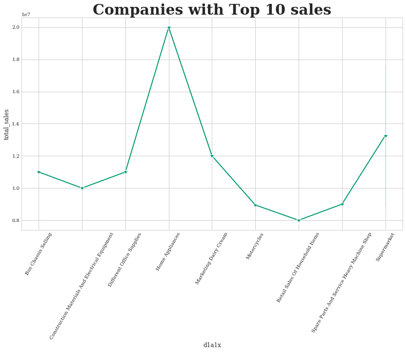

```python
plot_height = 8
plot_width = 14
fig, axs = plt.subplots(1, 1,figsize=(plot_width,plot_height))
plt.xticks(rotation=60)
#list(enumerate(axs))
#axs = axs.flatten()
sns.lineplot(x="d1a1x", y="total_sales", data=df_for_graph, color="#009973",marker="*",markersize=10).set_title("Companies with Top 10 sales",fontsize=30,fontweight='bold')
```

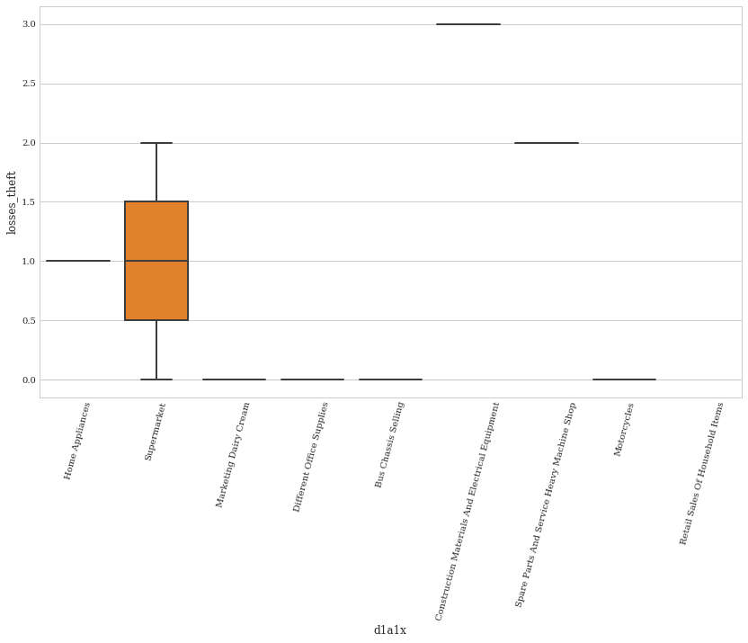

```python
plot_height = 8
plot_width = 14
fig, axs = plt.subplots(1, 1,figsize=(plot_width,plot_height))
plt.xticks(rotation=75)
sns.boxplot(x="d1a1x", y="losses_theft", data=df_for_graph)
```

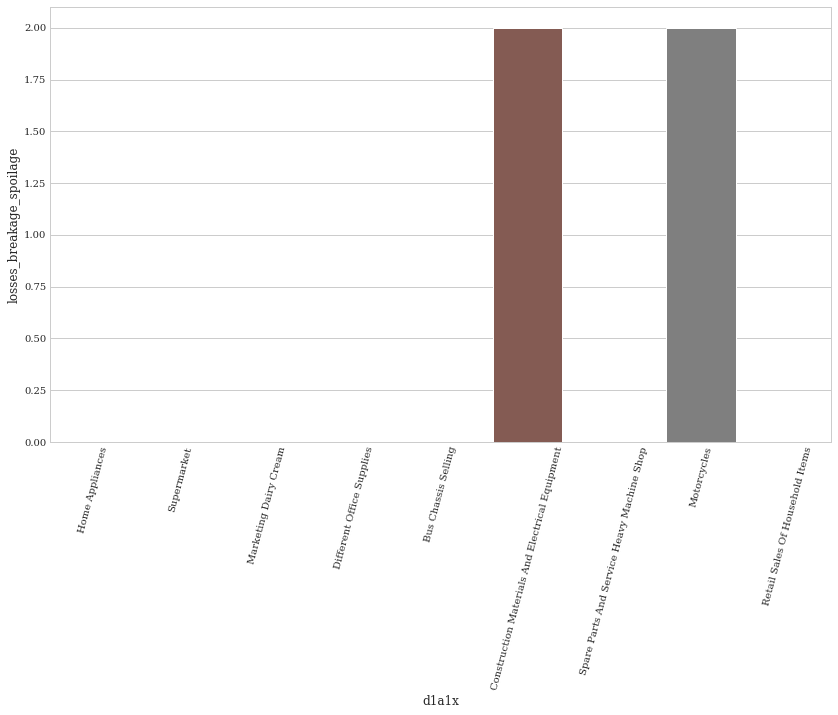

```python
plot_height = 8
plot_width = 14
fig, axs = plt.subplots(1, 1,figsize=(plot_width,plot_height))
plt.xticks(rotation=75)
sns.barplot(x="d1a1x", y="losses_breakage_spoilage", data=df_for_graph)
```

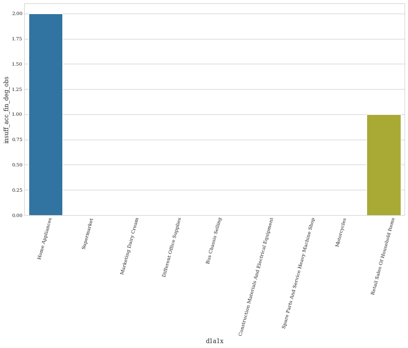

```python
plot_height = 8
plot_width = 14
fig, axs = plt.subplots(1, 1,figsize=(plot_width,plot_height))
plt.xticks(rotation=75)
sns.barplot(x="d1a1x", y="insuff_acc_fin_deg_obs", data=df_for_graph)
```

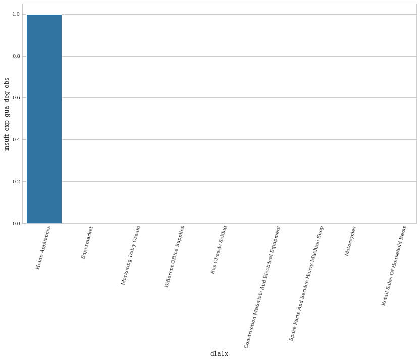

```python
plot_height = 8
plot_width = 14
fig, axs = plt.subplots(1, 1,figsize=(plot_width,plot_height))
plt.xticks(rotation=75)
sns.barplot(x="d1a1x", y="insuff_exp_gua_deg_obs", data=df_for_graph)
```

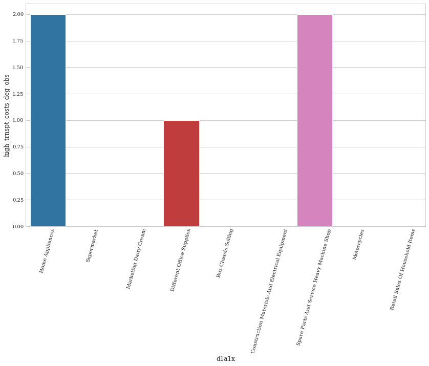

```python
plot_height = 8
plot_width = 14
fig, axs = plt.subplots(1, 1,figsize=(plot_width,plot_height))
plt.xticks(rotation=75)
sns.barplot(x="d1a1x", y="high_trnspt_costs_deg_obs", data=df_for_graph)
```

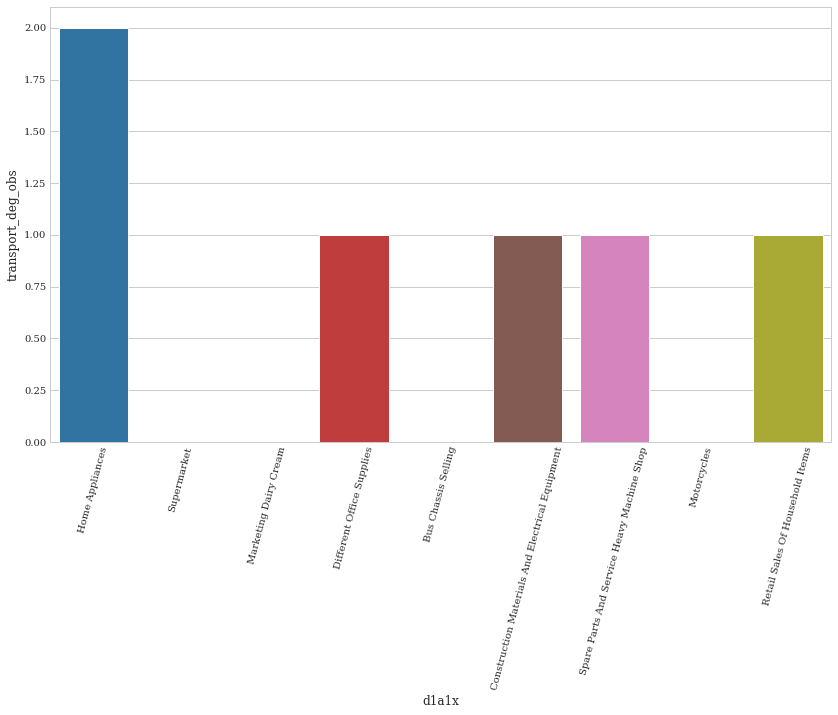

```python
plot_height = 8
plot_width = 14
fig, axs = plt.subplots(1, 1,figsize=(plot_width,plot_height))
plt.xticks(rotation=75)
sns.barplot(x="d1a1x", y="transport_deg_obs", data=df_for_graph)
```

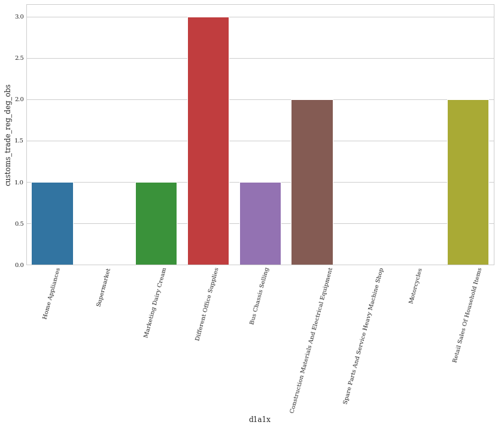

```python
plot_height = 8
plot_width = 14
fig, axs = plt.subplots(1, 1,figsize=(plot_width,plot_height))
plt.xticks(rotation=75)
sns.barplot(x="d1a1x", y="customs_trade_reg_deg_obs", data=df_for_graph)
```

```python
df_elsalvador_bl_co_merged.columns
```

```
Index(['idstd', 'id_x', 'd1a1x', 'd8', 'd14', 'transport_deg_obs',
       'customs_trade_reg_deg_obs', 'losses_theft', 'losses_breakage_spoilage',
       'total_sales_fy13', 'pct_sales_national_x',
       'pct_sales_indirect_exports_x', 'pct_sales_direct_exports_x',
       'total_sales', 'insuff_acc_fin_deg_obs', 'insuff_exp_gua_deg_obs',
       'high_trnspt_costs_deg_obs', 'LACd10e_deg_obs', 'is_export_fac_svc',
       'expect_vol_direct_exports', 'expect_vol_direct_exports_val',
       'is_prov_affect_cap_export', 'prov_affect_cap_export',
       'pct_sales_main_prod', 'pct_supplies_resell_domestic',
       'pct_supplies_resell_foreign', 'is_supplies_resell_imported_directly',
       'id_y', 'countryx', 'BPS5h', 'BPS5h1x', 'eligibilitycode',
       'estbl_status', 'is_estbl_closed_temp', 'no_weeks_estbl_closed',
       'is_sales_changed', 'pct_sales_incr', 'pct_sales_decr',
       'pct_sales_national_y', 'pct_sales_indirect_exports_y',
       'pct_sales_direct_exports_y', 'pct_dir_indir_exports_status',
       'is_estbl_adjusted', 'estbl_total_work_hrs_status',
       'estbl_demand_status', 'estbl_supply_inputs_status',
       'is_biz_actvty_online', 'is_delivery_goods_svc', 'is_remote_work_agmt',
       'is_digital_platforms_biz_admin',
       'is_digital_platforms_supply_chn_mgmt', 'is_digital_platforms_mktg',
       'is_digital_platforms_sale', 'is_digital_platforms_paymt_meth',
       'is_digital_platforms_svc_dvy', 'pct_workforce_remote',
       'pct_online_sales', 'pct_share_digi_pltms_web_sales',
       'is_estbl_invested_digi_sol'],
      dtype='object')
```

```python
df_for_graph_5 = df_elsalvador_bl_co_merged.query("pct_sales_incr > 0")
df_for_graph_6 = df_elsalvador_bl_co_merged.query("pct_sales_decr > 0")
print(df_for_graph_5.shape)
print(df_for_graph_6.shape)
df_for_graph_6 = df_elsalvador_bl_co_merged.query("pct_sales_decr > 0").sort_values(by='pct_sales_decr',ascending=False).head(10)
print(df_for_graph_6.shape)
```

```
(4, 59)
(68, 59)
(10, 59)
```

```python
df_for_graph_7=df_elsalvador_bl_co_merged.query("pct_sales_decr > 0").sort_values(by='pct_sales_decr',ascending=False).head(20)
```

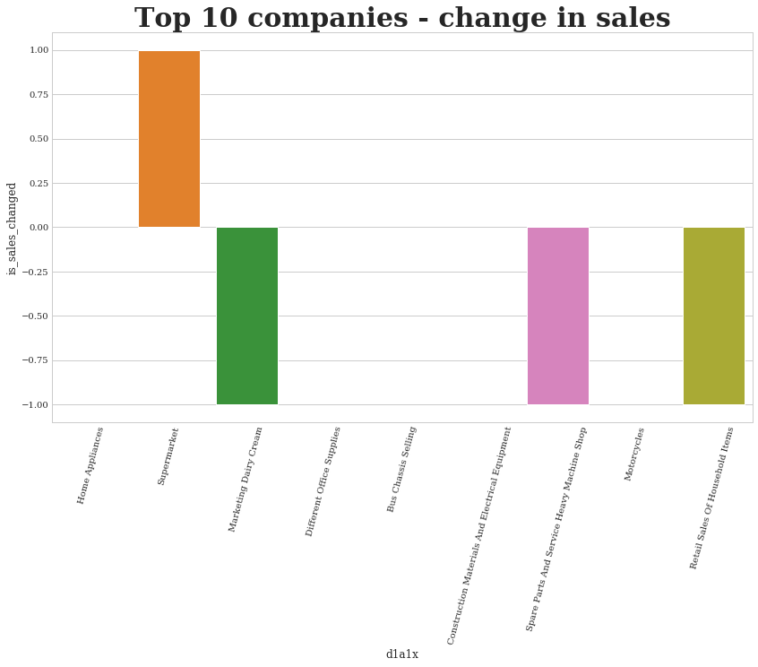

```python
plot_height = 8
plot_width = 14
fig, axs = plt.subplots(1, 1,figsize=(plot_width,plot_height))
plt.xticks(rotation=75)
sns.barplot(x="d1a1x", y="is_sales_changed", data=df_for_graph).set_title("Top 10 companies - change in sales",fontsize=30,fontweight='bold')
```

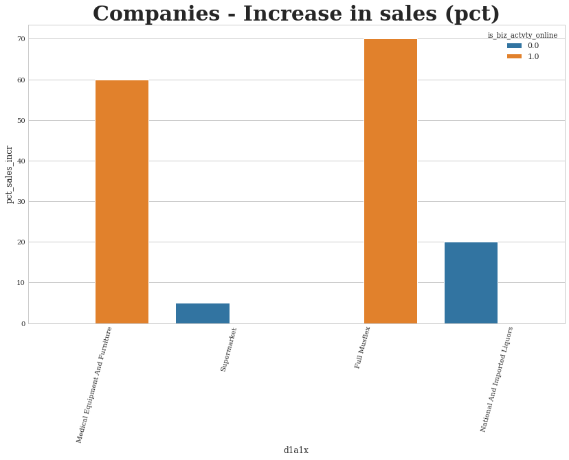

```python
plot_height = 8
plot_width = 14
fig, axs = plt.subplots(1, 1,figsize=(plot_width,plot_height))
plt.xticks(rotation=75)
sns.barplot(x="d1a1x", y="pct_sales_incr", data=df_for_graph_5,hue='is_biz_actvty_online').set_title("Companies - Increase in sales (pct)",fontsize=30,fontweight='bold')
```

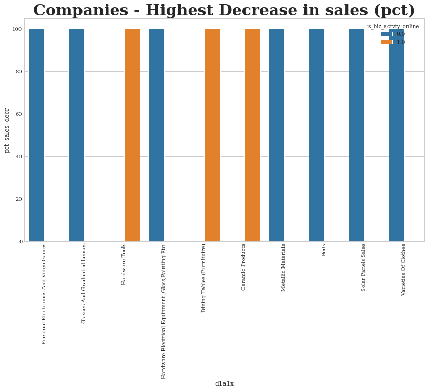

```python
plot_height = 8
plot_width = 14
fig, axs = plt.subplots(1, 1,figsize=(plot_width,plot_height))
plt.xticks(rotation=90)
sns.barplot(x="d1a1x", y="pct_sales_decr", data=df_for_graph_6,hue='is_biz_actvty_online').set_title("Companies - Highest Decrease in sales (pct)",fontsize=30,fontweight='bold')
```

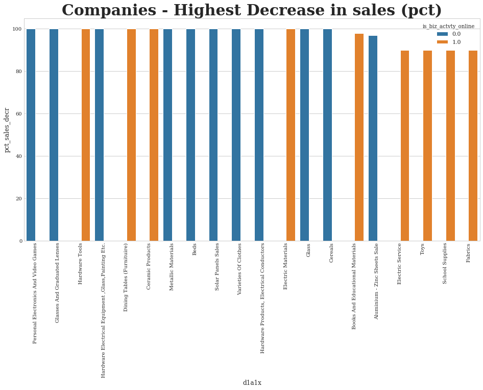

```python
plot_height = 8
plot_width = 16
fig, axs = plt.subplots(1, 1,figsize=(plot_width,plot_height))
plt.xticks(rotation=90)
sns.barplot(x="d1a1x", y="pct_sales_decr", data=df_for_graph_7,hue='is_biz_actvty_online').set_title("Companies - Highest Decrease in sales (pct)",fontsize=30,fontweight='bold')
```

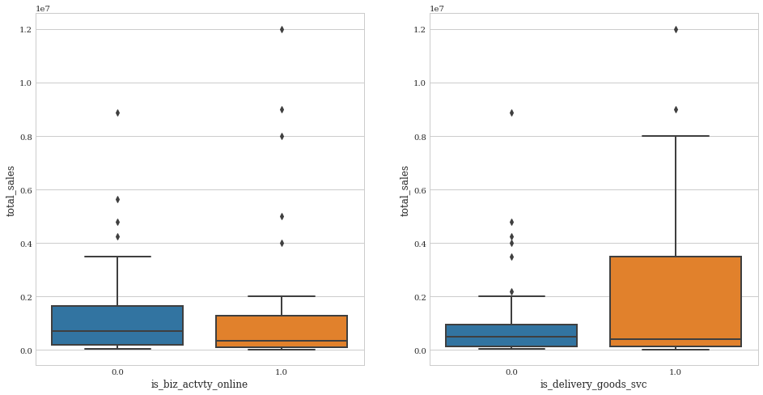

```python
plot_height = 8
plot_width = 16
fig, axs = plt.subplots(1, 2,figsize=(plot_width,plot_height))
sns.boxplot(x="is_biz_actvty_online", y="total_sales", data=df_elsalvador_bl_co_merged, ax=axs[0])
sns.boxplot(x="is_delivery_goods_svc", y="total_sales", data=df_elsalvador_bl_co_merged, ax=axs[1])
```

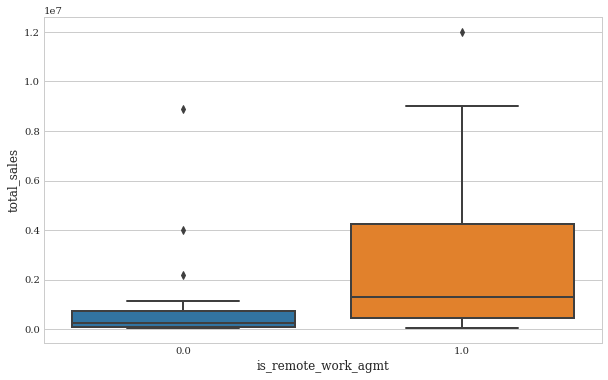

```python
plot_height = 6
plot_width = 10
fig, axs = plt.subplots(1, 1,figsize=(plot_width,plot_height))
sns.boxplot(x="is_remote_work_agmt", y="total_sales", data=df_elsalvador_bl_co_merged)
#sns.swarmplot(x="is_estbl_invested_digi_sol", y="total_sales", data=df_elsalvador_bl_co_merged, ax=axs[1])
```

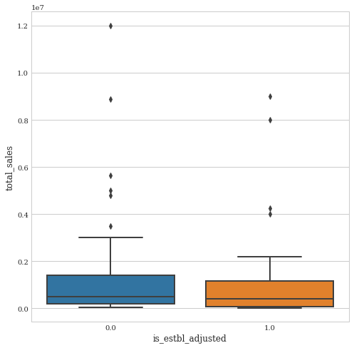

```python
plot_height = 8
plot_width = 8
fig, axs = plt.subplots(1, 1,figsize=(plot_width,plot_height))
sns.boxplot(x="is_estbl_adjusted", y="total_sales", data=df_elsalvador_bl_co_merged)
```

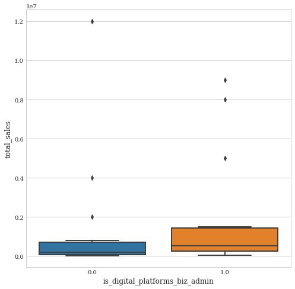

```python
plot_height = 8
plot_width = 8
fig, axs = plt.subplots(1, 1,figsize=(plot_width,plot_height))
sns.boxplot(x="is_digital_platforms_biz_admin", y="total_sales", data=df_elsalvador_bl_co_merged)
```

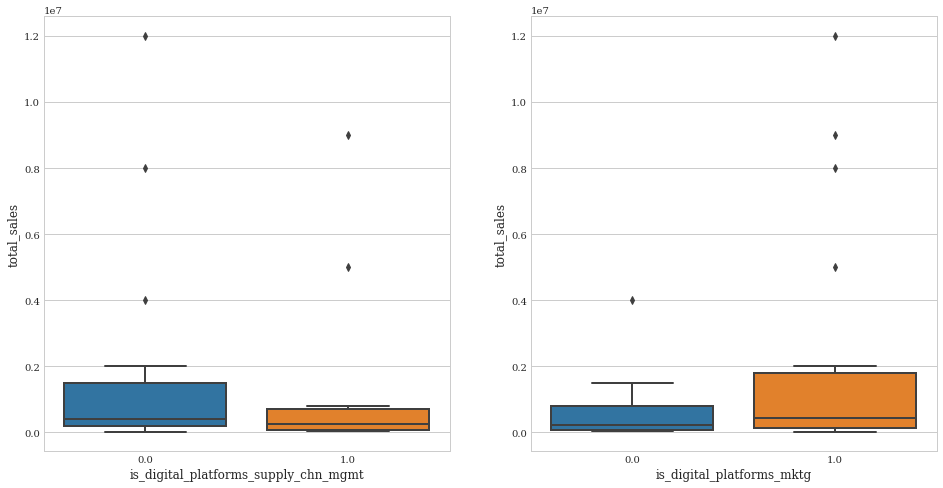

```python
plot_height = 8
plot_width = 16
fig, axs = plt.subplots(1, 2,figsize=(plot_width,plot_height))
sns.boxplot(x="is_digital_platforms_supply_chn_mgmt", y="total_sales", data=df_elsalvador_bl_co_merged, ax=axs[0])
sns.boxplot(x="is_digital_platforms_mktg", y="total_sales", data=df_elsalvador_bl_co_merged, ax=axs[1])
```

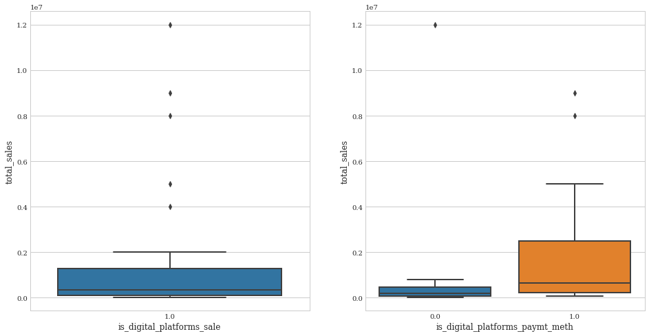

```python
plot_height = 8
plot_width = 16
fig, axs = plt.subplots(1, 2,figsize=(plot_width,plot_height))
sns.boxplot(x="is_digital_platforms_sale", y="total_sales", data=df_elsalvador_bl_co_merged, ax=axs[0])
sns.boxplot(x="is_digital_platforms_paymt_meth", y="total_sales", data=df_elsalvador_bl_co_merged, ax=axs[1])
```

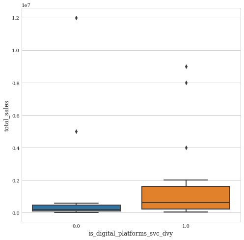

```python
plot_height = 8
plot_width = 8
fig, axs = plt.subplots(1, 1,figsize=(plot_width,plot_height))
sns.boxplot(x="is_digital_platforms_svc_dvy", y="total_sales", data=df_elsalvador_bl_co_merged)
```

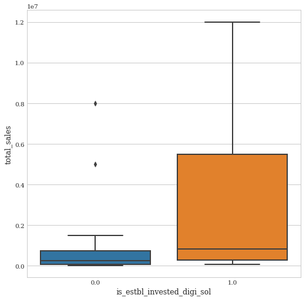

```python
plot_height = 8
plot_width = 8
fig, axs = plt.subplots(1, 1,figsize=(plot_width,plot_height))
sns.boxplot(x="is_estbl_invested_digi_sol", y="total_sales", data=df_elsalvador_bl_co_merged)
```

Please note: if 2020 total sales were available in the covid csv, then the boxplots could have been incorporated in the PPT. The above set of boxplot graphs have 2016 total sales on y-axis - from the baseline survey

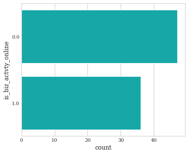

```python
sns.countplot(y="is_biz_actvty_online", data=df_elsalvador_bl_co_merged, color="c")
```

Graphs for Honduras:-

```python
df_for_graph_2 = df_honduras_bl_co_merged.sort_values(by='total_sales',ascending=False).head(10)
df_for_graph_2
```

|  | idstd | id_x | d1a1x | d8 | d14 | transport_deg_obs | customs_trade_reg_deg_obs | losses_theft | losses_breakage_spoilage | total_sales_fy13 | ... | is_digital_platforms_biz_admin | is_digital_platforms_supply_chn_mgmt | is_digital_platforms_mktg | is_digital_platforms_sale | is_digital_platforms_paymt_meth | is_digital_platforms_svc_dvy | pct_workforce_remote | pct_online_sales | pct_share_digi_pltms_web_sales | is_estbl_invested_digi_sol |
| --- | --- | --- | --- | --- | --- | --- | --- | --- | --- | --- | --- | --- | --- | --- | --- | --- | --- | --- | --- | --- | --- |
| 82 | 621330 | 14277 | Oil Transformers | 2005 | 60 | 2.0 | 3.0 | 0.0 | 2.0 | 795000000.0 | ... | 0.0 | 0.0 | 0.0 | 1.0 | 1.0 | 1.0 | 20.0 | NaN | 0.0 | 1.0 |
| 32 | 621190 | 4709 | Fuel | NaN | NaN | 3.0 | 0.0 | 1.0 | 0.0 | 400800000.0 | ... | NaN | NaN | NaN | NaN | NaN | NaN | NaN | NaN | NaN | NaN |
| 27 | 621182 | 4447 | Meats And Sausages | NaN | 20 | 2.0 | 3.0 | 0.0 | 2.0 | 400000000.0 | ... | 0.0 | 1.0 | 1.0 | 1.0 | 1.0 | 0.0 | 1.0 | 10.0 | 0.0 | 1.0 |
| 55 | 621235 | 7909 | Hardware Product | NaN | 12 | 2.0 | 2.0 | 0.0 | 1.0 | 150000000.0 | ... | NaN | NaN | NaN | NaN | NaN | NaN | NaN | NaN | NaN | NaN |
| 97 | 621363 | 15907 | Food Products | NaN | NaN | 1.0 | 0.0 | 0.0 | 0.0 | 85000000.0 | ... | 1.0 | 1.0 | 1.0 | 1.0 | 1.0 | 1.0 | 20.0 | 20.0 | 50.0 | 0.0 |
| 75 | 621305 | 12519 | Veterinary Product For Poultry, Pig, Reel | 2013 | 15 | 4.0 | 3.0 | 0.0 | 0.0 | 50000000.0 | ... | NaN | NaN | NaN | NaN | NaN | NaN | 0.0 | 0.0 | NaN | NaN |
| 98 | 621364 | 15917 | Building Materials | NaN | 5 | 1.0 | 1.0 | 0.0 | NaN | 63732589.0 | ... | NaN | NaN | NaN | NaN | NaN | NaN | NaN | NaN | NaN | NaN |
| 73 | 621301 | 12189 | Distribution Of Paintings (Paint Store) | NaN | 2 | 0.0 | 2.0 | 5.0 | 2.0 | 68000000.0 | ... | 1.0 | 0.0 | 1.0 | 1.0 | 1.0 | 1.0 | 50.0 | 0.0 | NaN | NaN |
| 15 | 621147 | 2028 | General Spare Parts And Industrial Equipment | NaN | 10 | 4.0 | 4.0 | 0.0 | 0.0 | 50000000.0 | ... | NaN | NaN | NaN | NaN | NaN | NaN | NaN | NaN | NaN | NaN |
| 109 | 621381 | 15973 | Cement For Construction | NaN | 7 | 2.0 | 3.0 | 0.0 | NaN | 45000000.0 | ... | 1.0 | 1.0 | 1.0 | 1.0 | 1.0 | 1.0 | 0.0 | NaN | 0.0 | 1.0 |

10 rows × 58 columns

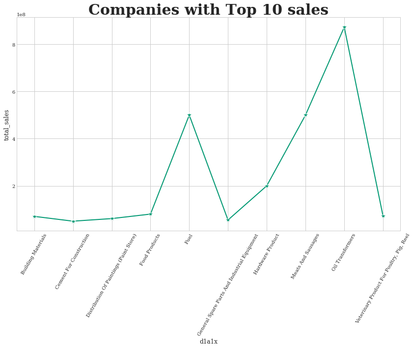

```python
plot_height = 8
plot_width = 14
fig, axs = plt.subplots(1, 1,figsize=(plot_width,plot_height))
plt.xticks(rotation=60)
#list(enumerate(axs))
#axs = axs.flatten()
sns.lineplot(x="d1a1x", y="total_sales", data=df_for_graph_2, color="#009973",marker="*",markersize=10).set_title("Companies with Top 10 sales",fontsize=30,fontweight='bold')
```

```python
#df_for_graph_2a = df_honduras_bl_co_merged.loc[df_honduras_bl_co_merged.is_sales_changed.isnull() == True]
#print(df_for_graph_2a.shape)
df_for_graph_3 = df_honduras_bl_co_merged.query("pct_sales_incr > 0")
df_for_graph_4 = df_honduras_bl_co_merged.query("pct_sales_decr > 0")
print(df_for_graph_3.shape)
print(df_for_graph_4.shape)
df_for_graph_4 = df_honduras_bl_co_merged.query("pct_sales_decr > 0").sort_values(by='pct_sales_decr',ascending=False).head(10)
print(df_for_graph_4.shape)
```

```
(5, 58)
(36, 58)
(10, 58)
```

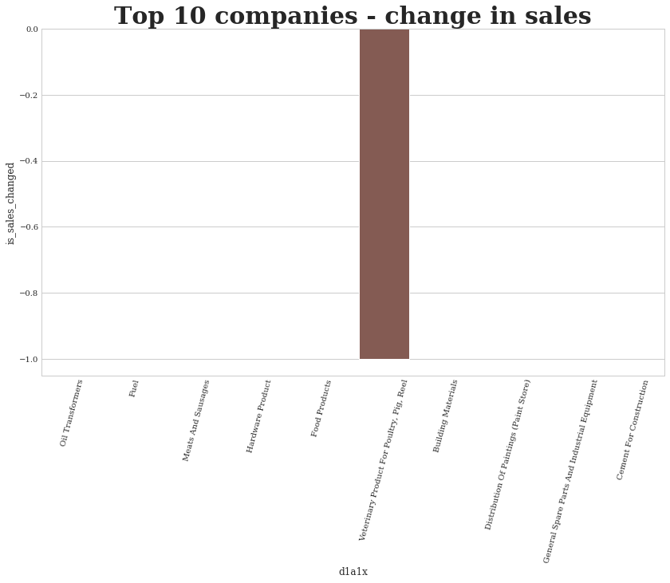

```python
plot_height = 8
plot_width = 14
fig, axs = plt.subplots(1, 1,figsize=(plot_width,plot_height))
plt.xticks(rotation=75)
sns.barplot(x="d1a1x", y="is_sales_changed", data=df_for_graph_2).set_title("Top 10 companies - change in sales",fontsize=30,fontweight='bold')
```

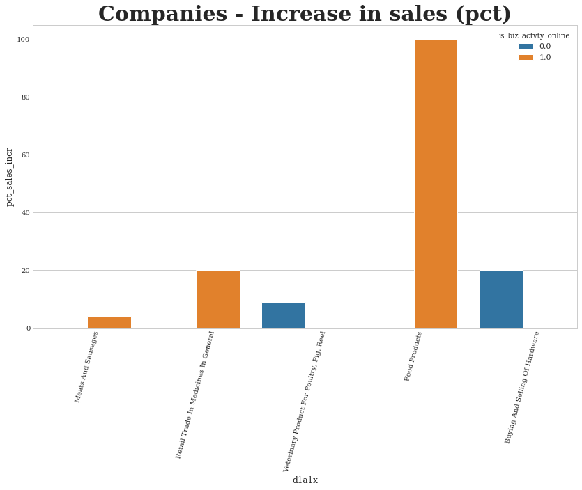

```python
plot_height = 8
plot_width = 14
fig, axs = plt.subplots(1, 1,figsize=(plot_width,plot_height))
plt.xticks(rotation=75)
sns.barplot(x="d1a1x", y="pct_sales_incr", data=df_for_graph_3,hue='is_biz_actvty_online').set_title("Companies - Increase in sales (pct)",fontsize=30,fontweight='bold')
```

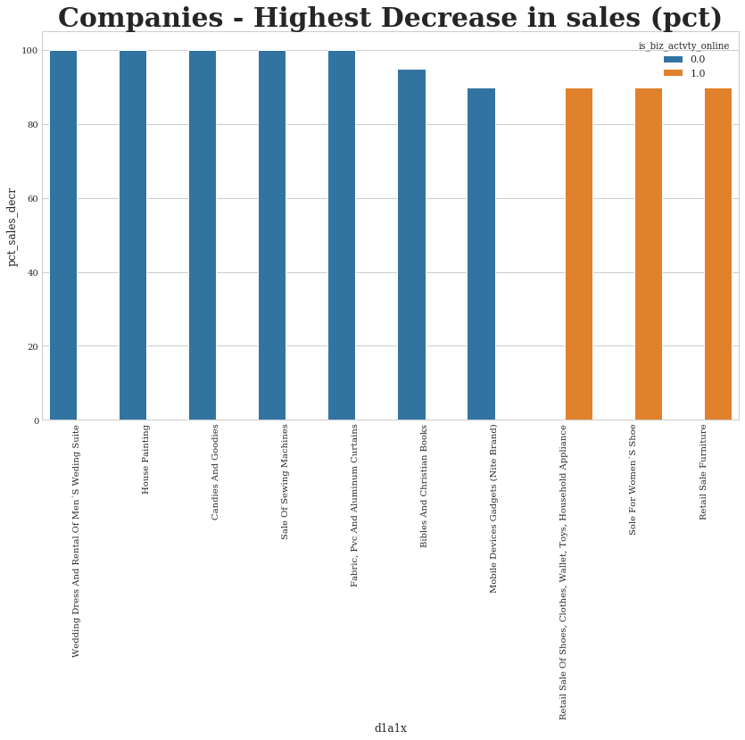

```python
plot_height = 8
plot_width = 14
fig, axs = plt.subplots(1, 1,figsize=(plot_width,plot_height))
plt.xticks(rotation=90)
sns.barplot(x="d1a1x", y="pct_sales_decr", data=df_for_graph_4,hue='is_biz_actvty_online').set_title("Companies - Highest Decrease in sales (pct)",fontsize=30,fontweight='bold')
```

```python
df_for_graph_8=df_honduras_bl_co_merged.query("pct_sales_decr > 0").sort_values(by='pct_sales_decr',ascending=False).head(20)
```

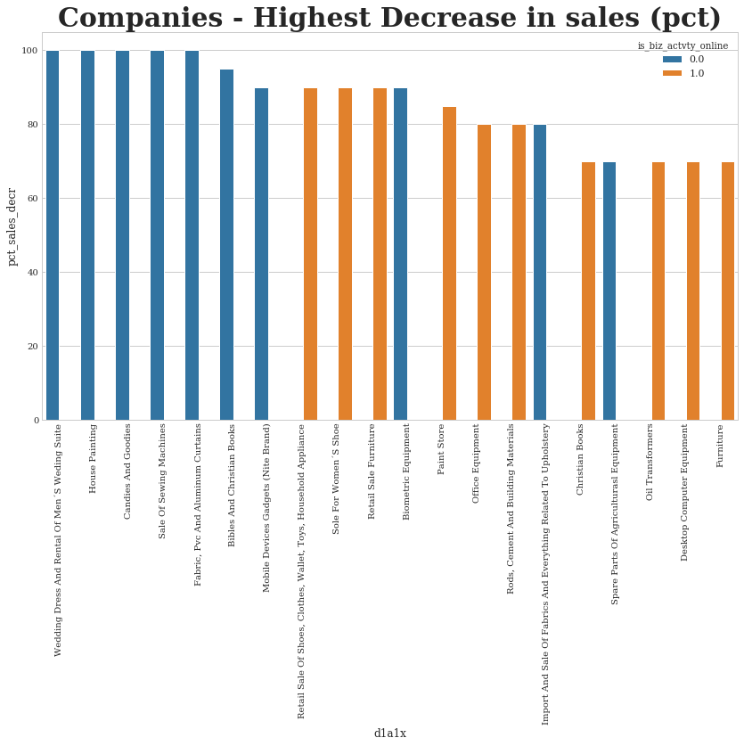

```python
plot_height = 8
plot_width = 14
fig, axs = plt.subplots(1, 1,figsize=(plot_width,plot_height))
plt.xticks(rotation=90)
sns.barplot(x="d1a1x", y="pct_sales_decr", data=df_for_graph_8,hue='is_biz_actvty_online').set_title("Companies - Highest Decrease in sales (pct)",fontsize=30,fontweight='bold')
```

Developing the Machine Learning Model:-

```python
df_elsalvador_baseline_filtered_level4.columns
```

```
Index(['idstd', 'id', 'd1a1x', 'd2x', 'd8', 'd14', 'transport_deg_obs',
       'customs_trade_reg_deg_obs', 'losses_theft', 'losses_breakage_spoilage',
       'total_sales_fy13', 'pct_sales_national', 'pct_sales_indirect_exports',
       'pct_sales_direct_exports', 'total_sales', 'insuff_acc_fin_deg_obs',
       'insuff_exp_gua_deg_obs', 'lack_staff_fr_trade_deg_obs',
       'high_trnspt_costs_deg_obs', 'LACd10e_deg_obs', 'is_export_fac_svc',
       'expect_vol_direct_exports', 'expect_vol_direct_exports_val',
       'is_prov_affect_cap_export', 'prov_affect_cap_export',
       'pct_sales_main_prod', 'pct_supplies_resell_domestic',
       'pct_supplies_resell_foreign', 'is_supplies_resell_imported_directly'],
      dtype='object')
```

```python
df_elsalvador_covid_filtered_level4.columns
```

```
Index(['idstd', 'id', 'countryx', 'BPS5h', 'BPS5h1x', 'eligibilitycode',
       'estbl_status', 'is_estbl_closed_temp', 'no_weeks_estbl_closed',
       'is_sales_changed', 'pct_sales_incr', 'pct_sales_decr',
       'pct_sales_national', 'pct_sales_indirect_exports',
       'pct_sales_direct_exports', 'pct_dir_indir_exports_status',
       'is_estbl_adjusted', 'estbl_total_work_hrs_status',
       'estbl_demand_status', 'estbl_supply_inputs_status',
       'is_biz_actvty_online', 'is_delivery_goods_svc', 'is_remote_work_agmt',
       'is_digital_platforms_biz_admin',
       'is_digital_platforms_supply_chn_mgmt', 'is_digital_platforms_mktg',
       'is_digital_platforms_sale', 'is_digital_platforms_paymt_meth',
       'is_digital_platforms_svc_dvy', 'pct_workforce_remote',
       'pct_online_sales', 'pct_share_digi_pltms_web_sales',
       'is_estbl_invested_digi_sol'],
      dtype='object')
```

```python
df_elsalvador_bl_co_merged.head()
```

|  | idstd | id_x | d1a1x | d8 | d14 | transport_deg_obs | customs_trade_reg_deg_obs | losses_theft | losses_breakage_spoilage | total_sales_fy13 | ... | is_digital_platforms_biz_admin | is_digital_platforms_supply_chn_mgmt | is_digital_platforms_mktg | is_digital_platforms_sale | is_digital_platforms_paymt_meth | is_digital_platforms_svc_dvy | pct_workforce_remote | pct_online_sales | pct_share_digi_pltms_web_sales | is_estbl_invested_digi_sol |
| --- | --- | --- | --- | --- | --- | --- | --- | --- | --- | --- | --- | --- | --- | --- | --- | --- | --- | --- | --- | --- | --- |
| 0 | 605675 | 6 | Personal Electronics And Video Games | NaN | 60 | 1.0 | 1.0 | 0.0 | 0.0 | 300000.0 | ... | NaN | NaN | NaN | NaN | NaN | NaN | 0.0 | 0.0 | NaN | NaN |
| 1 | 605677 | 8 | Books And Educational Materials | NaN | 2 | 0.0 | 0.0 | 0.0 | 0.0 | NaN | ... | 0.0 | 0.0 | 1.0 | 1.0 | 1.0 | 1.0 | 70.0 | 99.0 | 99.0 | 1.0 |
| 2 | 605679 | 11 | Sugar, Cereals | NaN | NaN | 2.0 | NaN | 0.0 | 0.0 | NaN | ... | NaN | NaN | NaN | NaN | NaN | NaN | 0.0 | 0.0 | NaN | NaN |
| 3 | 605681 | 14 | Pharmacy | NaN | NaN | 2.0 | 0.0 | 0.0 | 0.0 | NaN | ... | NaN | NaN | NaN | NaN | NaN | NaN | 0.0 | 0.0 | NaN | NaN |
| 4 | 605682 | 15 | Electric Materials | NaN | NaN | 0.0 | 1.0 | 0.0 | 0.0 | 3800000.0 | ... | 0.0 | 0.0 | 0.0 | 1.0 | 1.0 | 1.0 | 0.0 | 0.0 | NaN | NaN |

5 rows × 59 columns

```python
df_elsalvador_bl_co_merged.columns
```

```
Index(['idstd', 'id_x', 'd1a1x', 'd8', 'd14', 'transport_deg_obs',
       'customs_trade_reg_deg_obs', 'losses_theft', 'losses_breakage_spoilage',
       'total_sales_fy13', 'pct_sales_national_x',
       'pct_sales_indirect_exports_x', 'pct_sales_direct_exports_x',
       'total_sales', 'insuff_acc_fin_deg_obs', 'insuff_exp_gua_deg_obs',
       'high_trnspt_costs_deg_obs', 'LACd10e_deg_obs', 'is_export_fac_svc',
       'expect_vol_direct_exports', 'expect_vol_direct_exports_val',
       'is_prov_affect_cap_export', 'prov_affect_cap_export',
       'pct_sales_main_prod', 'pct_supplies_resell_domestic',
       'pct_supplies_resell_foreign', 'is_supplies_resell_imported_directly',
       'id_y', 'countryx', 'BPS5h', 'BPS5h1x', 'eligibilitycode',
       'estbl_status', 'is_estbl_closed_temp', 'no_weeks_estbl_closed',
       'is_sales_changed', 'pct_sales_incr', 'pct_sales_decr',
       'pct_sales_national_y', 'pct_sales_indirect_exports_y',
       'pct_sales_direct_exports_y', 'pct_dir_indir_exports_status',
       'is_estbl_adjusted', 'estbl_total_work_hrs_status',
       'estbl_demand_status', 'estbl_supply_inputs_status',
       'is_biz_actvty_online', 'is_delivery_goods_svc', 'is_remote_work_agmt',
       'is_digital_platforms_biz_admin',
       'is_digital_platforms_supply_chn_mgmt', 'is_digital_platforms_mktg',
       'is_digital_platforms_sale', 'is_digital_platforms_paymt_meth',
       'is_digital_platforms_svc_dvy', 'pct_workforce_remote',
       'pct_online_sales', 'pct_share_digi_pltms_web_sales',
       'is_estbl_invested_digi_sol'],
      dtype='object')
```

```python
df_elsalvador_bl_co_merged.is_sales_changed.unique()
```

```
array([-1., nan,  0.,  1.])
```

```python
df_elsalvador_bl_co_merged.is_sales_changed.isna().sum()
```

```
80
```

Filling the missing values:-

```python
df_elsalvador_bl_co_merged.fillna({'is_sales_changed' : 0}, inplace=True)
```

```python
df_elsalvador_bl_co_merged.is_sales_changed.isna().sum()
```

```
0
```

```python
df_elsalvador_bl_co_merged.is_sales_changed.unique()
```

```
array([-1.,  0.,  1.])
```

```python
def get_numerical_val_5(value):
    if value < 1:
        return 0
    else:
        return 1
```

```python
df_elsalvador_bl_co_merged['is_sales_increased'] = df_elsalvador_bl_co_merged['is_sales_changed'].apply(get_numerical_val_5)
df_elsalvador_bl_co_merged[['is_sales_changed','is_sales_increased']][df_elsalvador_bl_co_merged.is_sales_changed < 0]
```

|  | is_sales_changed | is_sales_increased |
| --- | --- | --- |
| 0 | -1.0 | 0 |
| 1 | -1.0 | 0 |
| 2 | -1.0 | 0 |
| 3 | -1.0 | 0 |
| 4 | -1.0 | 0 |
| ... | ... | ... |
| 148 | -1.0 | 0 |
| 153 | -1.0 | 0 |
| 157 | -1.0 | 0 |
| 158 | -1.0 | 0 |
| 160 | -1.0 | 0 |

70 rows × 2 columns

```python
df_elsalvador_bl_co_merged[['is_sales_changed','is_sales_increased']][df_elsalvador_bl_co_merged.is_sales_changed == 0]
```

|  | is_sales_changed | is_sales_increased |
| --- | --- | --- |
| 5 | 0.0 | 0 |
| 7 | 0.0 | 0 |
| 8 | 0.0 | 0 |
| 9 | 0.0 | 0 |
| 10 | 0.0 | 0 |
| ... | ... | ... |
| 155 | 0.0 | 0 |
| 156 | 0.0 | 0 |
| 159 | 0.0 | 0 |
| 161 | 0.0 | 0 |
| 162 | 0.0 | 0 |

89 rows × 2 columns

```python
df_elsalvador_bl_co_merged[['is_sales_changed','is_sales_increased']][df_elsalvador_bl_co_merged.is_sales_changed == 1]
```

|  | is_sales_changed | is_sales_increased |
| --- | --- | --- |
| 26 | 1.0 | 1 |
| 66 | 1.0 | 1 |
| 99 | 1.0 | 1 |
| 121 | 1.0 | 1 |

#### Model 1:- El Salvador - We shall go with the Random Forest Classifier with GridSearchCV Dependent Variable to predict - is_sales_increased - Categorical Variable - corresponds to the question no. 'COVb2a' of the survey

```python
df_elsalvador_bl_co_merged2 = df_elsalvador_bl_co_merged.drop(columns=['idstd', 'id_x', 'd1a1x', 'd8', 'd14',
       'losses_theft', 'losses_breakage_spoilage',
       'total_sales','total_sales_fy13','pct_sales_national_x',
       'pct_sales_indirect_exports_x', 'pct_sales_direct_exports_x',
       'is_sales_changed','is_export_fac_svc',
       'expect_vol_direct_exports', 'expect_vol_direct_exports_val',
       'is_prov_affect_cap_export', 'prov_affect_cap_export',
       'pct_sales_main_prod', 'pct_supplies_resell_domestic',
       'pct_supplies_resell_foreign', 'is_supplies_resell_imported_directly',
       'id_y', 'countryx', 'BPS5h', 'BPS5h1x', 'eligibilitycode'
       ])
df_elsalvador_bl_co_merged2
```

|  | transport_deg_obs | customs_trade_reg_deg_obs | insuff_acc_fin_deg_obs | insuff_exp_gua_deg_obs | high_trnspt_costs_deg_obs | LACd10e_deg_obs | estbl_status | is_estbl_closed_temp | no_weeks_estbl_closed | pct_sales_incr | ... | is_digital_platforms_supply_chn_mgmt | is_digital_platforms_mktg | is_digital_platforms_sale | is_digital_platforms_paymt_meth | is_digital_platforms_svc_dvy | pct_workforce_remote | pct_online_sales | pct_share_digi_pltms_web_sales | is_estbl_invested_digi_sol | is_sales_increased |
| --- | --- | --- | --- | --- | --- | --- | --- | --- | --- | --- | --- | --- | --- | --- | --- | --- | --- | --- | --- | --- | --- |
| 0 | 1.0 | 1.0 | 0.0 | 0.0 | 0.0 | 0.0 | 0.0 | NaN | 15.0 | NaN | ... | NaN | NaN | NaN | NaN | NaN | 0.0 | 0.0 | NaN | NaN | 0 |
| 1 | 0.0 | 0.0 | 0.0 | 0.0 | 0.0 | 0.0 | 1.0 | 1.0 | 12.0 | NaN | ... | 0.0 | 1.0 | 1.0 | 1.0 | 1.0 | 70.0 | 99.0 | 99.0 | 1.0 | 0 |
| 2 | 2.0 | NaN | 0.0 | NaN | NaN | 2.0 | 1.0 | 0.0 | NaN | NaN | ... | NaN | NaN | NaN | NaN | NaN | 0.0 | 0.0 | NaN | NaN | 0 |
| 3 | 2.0 | 0.0 | 1.0 | 2.0 | 2.0 | 2.0 | 1.0 | 0.0 | NaN | NaN | ... | NaN | NaN | NaN | NaN | NaN | 0.0 | 0.0 | NaN | NaN | 0 |
| 4 | 0.0 | 1.0 | 0.0 | NaN | NaN | NaN | 1.0 | 1.0 | 4.0 | NaN | ... | 0.0 | 0.0 | 1.0 | 1.0 | 1.0 | 0.0 | 0.0 | NaN | NaN | 0 |
| ... | ... | ... | ... | ... | ... | ... | ... | ... | ... | ... | ... | ... | ... | ... | ... | ... | ... | ... | ... | ... | ... |
| 158 | 1.0 | 1.0 | 3.0 | 2.0 | 2.0 | 1.0 | 0.0 | NaN | 10.0 | NaN | ... | 1.0 | 1.0 | 1.0 | 1.0 | 0.0 | 0.0 | 100.0 | 0.0 | 0.0 | 0 |
| 159 | 1.0 | 1.0 | 3.0 | 0.0 | 1.0 | 1.0 | NaN | NaN | NaN | NaN | ... | NaN | NaN | NaN | NaN | NaN | NaN | NaN | NaN | NaN | 0 |
| 160 | 0.0 | 0.0 | NaN | NaN | NaN | NaN | 1.0 | 1.0 | 10.0 | NaN | ... | NaN | NaN | NaN | NaN | NaN | 0.0 | 0.0 | NaN | NaN | 0 |
| 161 | 1.0 | 0.0 | 0.0 | 0.0 | 1.0 | 1.0 | NaN | NaN | NaN | NaN | ... | NaN | NaN | NaN | NaN | NaN | NaN | NaN | NaN | NaN | 0 |
| 162 | 0.0 | 0.0 | 1.0 | 0.0 | 0.0 | 1.0 | NaN | NaN | NaN | NaN | ... | NaN | NaN | NaN | NaN | NaN | NaN | NaN | NaN | NaN | 0 |

163 rows × 33 columns

```python
yvar= df_elsalvador_bl_co_merged2.is_sales_increased.astype('float64')
Xvar = df_elsalvador_bl_co_merged2.drop(['is_sales_increased'], axis=1).astype('float64')
```

```python
# Split the data into training and test portions:

X2_train, X2_test, Y2_train, Y2_test = train_test_split(Xvar, yvar, test_size=0.25, random_state=7)
print(X2_train.shape, Y2_train.shape)
print(X2_test.shape, Y2_test.shape)
```

```
(122, 32) (122,)
(41, 32) (41,)
```

```python
# Select the model approach for fitting: RandomForest Classifier

DT_sales_rfc = RandomForestClassifier(random_state=23)
```

```python
# set the gridsearch parameters for the RandomForest Classifier
dtfc_param_grid={'n_estimators': [10, 15, 20], 'max_depth':[5, 10, 15], \
                 'max_leaf_nodes':np.arange(2,10), 'min_samples_split':[5, 10, 15]}
```

```python
# define the gridsearch for decision tree classification:
dtrfc_grid_search = GridSearchCV(DT_sales_rfc, dtfc_param_grid, cv=5, scoring='accuracy')
```

```python
# Fit the model on training data
# Since we are using the training portion of the data, we are now "training" our model.
dtrfc_grid_search.fit(X2_train, Y2_train)
```

[output not shown]

[output cut: 4267 more lines]

[output not shown]

[output not shown]

```python
df_elsalvador_bl_co_merged2.info()
```

```
<class 'pandas.core.frame.DataFrame'>
Int64Index: 163 entries, 0 to 162
Data columns (total 33 columns):
 #   Column                                Non-Null Count  Dtype
---  ------                                --------------  -----
 0   transport_deg_obs                     160 non-null    float64
 1   customs_trade_reg_deg_obs             148 non-null    float64
 2   insuff_acc_fin_deg_obs                134 non-null    float64
 3   insuff_exp_gua_deg_obs                122 non-null    float64
 4   high_trnspt_costs_deg_obs             121 non-null    float64
 5   LACd10e_deg_obs                       128 non-null    float64
 6   estbl_status                          84 non-null     float64
 7   is_estbl_closed_temp                  70 non-null     float64
 8   no_weeks_estbl_closed                 58 non-null     float64
 9   pct_sales_incr                        4 non-null      float64
```

[output cut: 25 more lines]

Initially assigned 0 to new variables when value is Dont know or Does not apply in original variable. Later changed it by assigning NaN, which increased the number of NaN values to the existing null values in csv  
Also, each row in the dataFrame corresponds to a company and it is tricky to fill the missing data. We cannot use median or mean values to fill the missing data for any column as this would apply to all rows wherever null value is present such as *dfSoy.fillna({'precip' : dfSoy['precip'].mean(), 'temp':dfSoy['temp'].median()}, inplace=True)*  
because the survey is not for a single entity but multiple entities/companies and we cannot generalize the sales figure or the obstacles faced, percentage sales direct, indirect exports etc. if the value is Dont know because all these attributes are company-specific, therefore cant be generalized per se.

```python
df_elsalvador_bl_co_merged2.fillna(0,inplace=True)
```

Let us re-build the model:-

### These are the input/output variables

```python
yvar= df_elsalvador_bl_co_merged2.is_sales_increased.astype('float64')
Xvar = df_elsalvador_bl_co_merged2.drop(['is_sales_increased'], axis=1).astype('float64')
```

```python
# Split the data into training and test portions:

X2_train, X2_test, Y2_train, Y2_test = train_test_split(Xvar, yvar, test_size=0.25, random_state=7)
print(X2_train.shape, Y2_train.shape)
print(X2_test.shape, Y2_test.shape)
```

```
(122, 32) (122,)
(41, 32) (41,)
```

#### We shall go with the Random Forest Classifier

```python
# Select the model approach for fitting: RandomForest Classifier

DT_sales_rfc = RandomForestClassifier(random_state=23)
```

```python
# set the gridsearch parameters for the RandomForest Classifier
dtfc_param_grid={'n_estimators': [10, 15, 20], 'max_depth':[5, 10, 15], \
                 'max_leaf_nodes':np.arange(2,10), 'min_samples_split':[5, 10, 15]}
```

```python
# define the gridsearch for decision tree classification:
dtrfc_grid_search = GridSearchCV(DT_sales_rfc, dtfc_param_grid, cv=5, scoring='accuracy')
```

```python
# Fit the model on training data
# Since we are using the training portion of the data, we are now "training" our model.
dtrfc_grid_search.fit(X2_train, Y2_train)
```

```
GridSearchCV(cv=5, error_score=nan,
             estimator=RandomForestClassifier(bootstrap=True, ccp_alpha=0.0,
                                              class_weight=None,
                                              criterion='gini', max_depth=None,
                                              max_features='auto',
                                              max_leaf_nodes=None,
                                              max_samples=None,
                                              min_impurity_decrease=0.0,
                                              min_impurity_split=None,
                                              min_samples_leaf=1,
                                              min_samples_split=2,
                                              min_weight_fraction_leaf=0.0,
                                              n_estimators=100, n_jobs=None,
                                              oob_score=False, random_state=23,
                                              verbose=0, warm_start=False),
             iid='deprecated', n_jobs=None,
             param_grid={'max_depth': [5, 10, 15],
                         'max_leaf_nodes': array([2, 3, 4, 5, 6, 7, 8, 9]),
                         'min_samples_split': [5, 10, 15],
                         'n_estimators': [10, 15, 20]},
             pre_dispatch='2*n_jobs', refit=True, return_train_score=False,
             scoring='accuracy', verbose=0)
```

```python
dtrfc_grid_search.cv_results_['mean_test_score']
```

```
array([0.984, 0.984, 0.984, 0.984, 0.984, 0.984, 0.984, 0.984, 0.984,
       0.984, 0.984, 0.984, 0.984, 0.984, 0.984, 0.984, 0.984, 0.984,
       0.984, 0.984, 0.984, 0.984, 0.984, 0.984, 0.984, 0.984, 0.984,
       0.984, 0.984, 0.984, 0.984, 0.984, 0.984, 0.984, 0.984, 0.984,
       0.984, 0.984, 0.984, 0.984, 0.984, 0.984, 0.984, 0.984, 0.984,
       0.984, 0.984, 0.984, 0.984, 0.984, 0.984, 0.984, 0.984, 0.984,
       0.984, 0.984, 0.984, 0.984, 0.984, 0.984, 0.984, 0.984, 0.984,
       0.984, 0.984, 0.984, 0.984, 0.984, 0.984, 0.984, 0.984, 0.984,
       0.984, 0.984, 0.984, 0.984, 0.984, 0.984, 0.984, 0.984, 0.984,
       0.984, 0.984, 0.984, 0.984, 0.984, 0.984, 0.984, 0.984, 0.984,
       0.984, 0.984, 0.984, 0.984, 0.984, 0.984, 0.984, 0.984, 0.984,
       0.984, 0.984, 0.984, 0.984, 0.984, 0.984, 0.984, 0.984, 0.984,
       0.984, 0.984, 0.984, 0.984, 0.984, 0.984, 0.984, 0.984, 0.984,
       0.984, 0.984, 0.984, 0.984, 0.984, 0.984, 0.984, 0.984, 0.984,
       0.984, 0.984, 0.984, 0.984, 0.984, 0.984, 0.984, 0.984, 0.984,
       0.984, 0.984, 0.984, 0.984, 0.984, 0.984, 0.984, 0.984, 0.984,
       0.984, 0.984, 0.984, 0.984, 0.984, 0.984, 0.984, 0.984, 0.984,
       0.984, 0.984, 0.984, 0.984, 0.984, 0.984, 0.984, 0.984, 0.984,
       0.984, 0.984, 0.984, 0.984, 0.984, 0.984, 0.984, 0.984, 0.984,
       0.984, 0.984, 0.984, 0.984, 0.984, 0.984, 0.984, 0.984, 0.984,
       0.984, 0.984, 0.984, 0.984, 0.984, 0.984, 0.984, 0.984, 0.984,
       0.984, 0.984, 0.984, 0.984, 0.984, 0.984, 0.984, 0.984, 0.984,
       0.984, 0.984, 0.984, 0.984, 0.984, 0.984, 0.984, 0.984, 0.984,
       0.984, 0.984, 0.984, 0.984, 0.984, 0.984, 0.984, 0.984, 0.984])
```

```python
dtrfc_grid_search.best_params_
```

```
{'max_depth': 5,
 'max_leaf_nodes': 2,
 'min_samples_split': 5,
 'n_estimators': 10}
```

```python
dtrfc_grid_search.best_estimator_
```

```
RandomForestClassifier(bootstrap=True, ccp_alpha=0.0, class_weight=None,
                       criterion='gini', max_depth=5, max_features='auto',
                       max_leaf_nodes=2, max_samples=None,
                       min_impurity_decrease=0.0, min_impurity_split=None,
                       min_samples_leaf=1, min_samples_split=5,
                       min_weight_fraction_leaf=0.0, n_estimators=10,
                       n_jobs=None, oob_score=False, random_state=23, verbose=0,
                       warm_start=False)
```

```python
# Get the predictions of the best Random Forest classifier
DTrfc_prediction_ctc=dtrfc_grid_search.best_estimator_.predict(X2_test)
```

```python
# Evaluate how good the Random Forest classification is:
cm_DTC = confusion_matrix(Y2_test, DTrfc_prediction_ctc)
print("Confusion Matrix:\n", cm_DTC)
print("\n")
print("Classification Report:\n",classification_report(Y2_test, DTrfc_prediction_ctc))
```

```
Confusion Matrix:
 [[39  0]
 [ 2  0]]


Classification Report:
               precision    recall  f1-score   support

         0.0       0.95      1.00      0.97        39
         1.0       0.00      0.00      0.00         2

    accuracy                           0.95        41
   macro avg       0.48      0.50      0.49        41
weighted avg       0.90      0.95      0.93        41
```

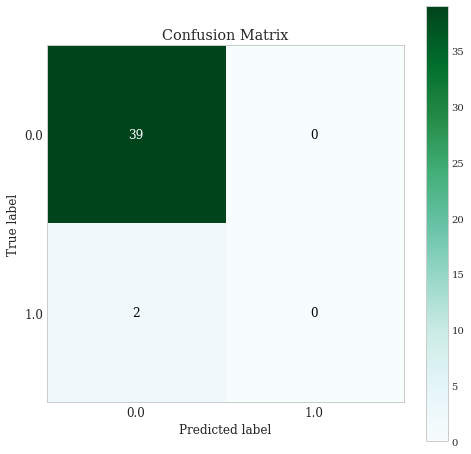

```python
skplt.metrics.plot_confusion_matrix(Y2_test, DTrfc_prediction_ctc, figsize=(8,8), cmap="BuGn")
```

Interpretation: We see that the model is exactly similar to a naive prediction!

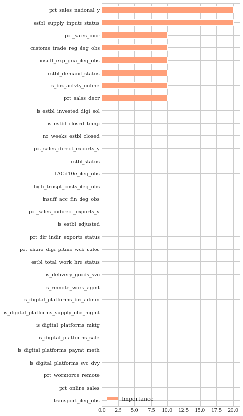

```python
sales_features=df_elsalvador_bl_co_merged2.drop(['is_sales_increased'], axis=1).columns
%matplotlib inline
Importance = pd.DataFrame({'Importance':dtrfc_grid_search.best_estimator_.feature_importances_*100}, \
                          index=sales_features)
Importance.sort_values('Importance', axis=0, ascending=True).plot(kind='barh', color='lightsalmon', )
plt.gcf().set_size_inches(5, 15)
```

#### Model 2:- El Salvador - Now, we got the best paramters, so we shall build another model - Dependent Variable to predict - is_sales_increased - Categorical Variable:- - corresponds to the question no. 'COVb2a' of the survey

```python
df_elsalvador_bl_co_merged2.columns
```

```
Index(['transport_deg_obs', 'customs_trade_reg_deg_obs',
       'insuff_acc_fin_deg_obs', 'insuff_exp_gua_deg_obs',
       'high_trnspt_costs_deg_obs', 'LACd10e_deg_obs', 'estbl_status',
       'is_estbl_closed_temp', 'no_weeks_estbl_closed', 'pct_sales_incr',
       'pct_sales_decr', 'pct_sales_national_y',
       'pct_sales_indirect_exports_y', 'pct_sales_direct_exports_y',
       'pct_dir_indir_exports_status', 'is_estbl_adjusted',
       'estbl_total_work_hrs_status', 'estbl_demand_status',
       'estbl_supply_inputs_status', 'is_biz_actvty_online',
       'is_delivery_goods_svc', 'is_remote_work_agmt',
       'is_digital_platforms_biz_admin',
       'is_digital_platforms_supply_chn_mgmt', 'is_digital_platforms_mktg',
       'is_digital_platforms_sale', 'is_digital_platforms_paymt_meth',
       'is_digital_platforms_svc_dvy', 'pct_workforce_remote',
       'pct_online_sales', 'pct_share_digi_pltms_web_sales',
       'is_estbl_invested_digi_sol', 'is_sales_increased'],
      dtype='object')
```

### These are the input/output variables

```python
yvar= df_elsalvador_bl_co_merged2.is_sales_increased.astype('float64')
Xvar = df_elsalvador_bl_co_merged2.drop(['transport_deg_obs',
       'insuff_acc_fin_deg_obs',
       'high_trnspt_costs_deg_obs', 'LACd10e_deg_obs', 'estbl_status',
       'is_estbl_closed_temp', 'no_weeks_estbl_closed',
       'pct_sales_indirect_exports_y', 'pct_sales_direct_exports_y',
       'pct_dir_indir_exports_status', 'is_estbl_adjusted',
       'estbl_total_work_hrs_status',
       'is_delivery_goods_svc', 'is_remote_work_agmt',
       'is_digital_platforms_biz_admin',
       'is_digital_platforms_supply_chn_mgmt', 'is_digital_platforms_mktg',
       'is_digital_platforms_sale', 'is_digital_platforms_paymt_meth',
       'is_digital_platforms_svc_dvy', 'pct_workforce_remote',
       'pct_online_sales', 'pct_share_digi_pltms_web_sales',
       'is_estbl_invested_digi_sol','is_sales_increased'], axis=1).astype('float64')
Xvar.columns
```

```
Index(['customs_trade_reg_deg_obs', 'insuff_exp_gua_deg_obs', 'pct_sales_incr',
       'pct_sales_decr', 'pct_sales_national_y', 'estbl_demand_status',
       'estbl_supply_inputs_status', 'is_biz_actvty_online'],
      dtype='object')
```

```python
# Split the data into training and test portions:

X2_train, X2_test, Y2_train, Y2_test = train_test_split(Xvar, yvar, test_size=0.25, random_state=7)
print(X2_train.shape, Y2_train.shape)
print(X2_test.shape, Y2_test.shape)
```

```
(122, 8) (122,)
(41, 8) (41,)
```

Building and Invoking the Random Forest Classifier

```python
# Select the model approach for fitting: RandomForest Classifier

DT_sales_rfc = RandomForestClassifier(max_depth= 5,
 max_leaf_nodes= 2,
 min_samples_split= 5,
 n_estimators= 10,random_state=23)
```

```python
# Fit the decision tree random forest classifier models with training data:
DT_sales_rfc.fit(X2_train, Y2_train)
```

```
RandomForestClassifier(bootstrap=True, ccp_alpha=0.0, class_weight=None,
                       criterion='gini', max_depth=5, max_features='auto',
                       max_leaf_nodes=2, max_samples=None,
                       min_impurity_decrease=0.0, min_impurity_split=None,
                       min_samples_leaf=1, min_samples_split=5,
                       min_weight_fraction_leaf=0.0, n_estimators=10,
                       n_jobs=None, oob_score=False, random_state=23, verbose=0,
                       warm_start=False)
```

```python
# Get the predictions of the random forest classifiers on testing data

DTRF_prediction_ctt=DT_sales_rfc.predict(X2_test)
```

#### Evaluating how good the random forest classification is:

```python
cm_DTC_RF = confusion_matrix(Y2_test, DTRF_prediction_ctt)
print("Confusion Matrix:\n",cm_DTC_RF)
print("\n")
print("Classification Report:\n",classification_report(Y2_test, DTRF_prediction_ctt))
```

```
Confusion Matrix:
 [[39  0]
 [ 1  1]]


Classification Report:
               precision    recall  f1-score   support

         0.0       0.97      1.00      0.99        39
         1.0       1.00      0.50      0.67         2

    accuracy                           0.98        41
   macro avg       0.99      0.75      0.83        41
weighted avg       0.98      0.98      0.97        41
```

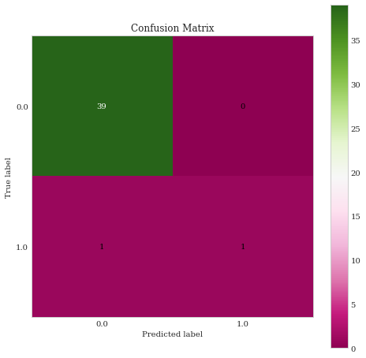

```python
skplt.metrics.plot_confusion_matrix(Y2_test, DTRF_prediction_ctt, figsize=(8,8), cmap="PiYG")
```

Interpretation:

- The random forest model identified 1 company correctly that the sales increased despite covid, missed 1 comp.

Are these predictions better than a naive prediction? A naive prediction is to say that "the sales will not increase".

```python
1-df_elsalvador_bl_co_merged2.is_sales_increased.mean()
```

```
0.9754601226993865
```

Takeaway: This was a difficult prediction, as even the naive prediction yields high accuracy.

```python
print(df_elsalvador_bl_co_merged.pct_sales_incr.isna().sum())
print(df_elsalvador_bl_co_merged.pct_sales_decr.isna().sum())
print(df_elsalvador_bl_co_merged.shape)
```

```
159
95
(163, 60)
```

```python
df_elsalvador_bl_co_merged1 = df_elsalvador_bl_co_merged.dropna(axis=0, subset=['pct_sales_decr'])
print(df_elsalvador_bl_co_merged1.shape)
```

```
(68, 60)
```

#### Model 3: El Salvador - Let us build another model - This time we would predict a continous variable - The percentage decrease in Sales due to Covid

Dependent Variable to predict - pct_sales_decr - Continous Variable - corresponds to the question no. 'COVb2c' of the survey

- As the null values for pct_sales_incr are more, let us go with the pct_sales_decr as the Dependent Variable

```python
df_elsalvador_bl_co_merged.columns
```

```
Index(['idstd', 'id_x', 'd1a1x', 'd8', 'd14', 'transport_deg_obs',
       'customs_trade_reg_deg_obs', 'losses_theft', 'losses_breakage_spoilage',
       'total_sales_fy13', 'pct_sales_national_x',
       'pct_sales_indirect_exports_x', 'pct_sales_direct_exports_x',
       'total_sales', 'insuff_acc_fin_deg_obs', 'insuff_exp_gua_deg_obs',
       'high_trnspt_costs_deg_obs', 'LACd10e_deg_obs', 'is_export_fac_svc',
       'expect_vol_direct_exports', 'expect_vol_direct_exports_val',
       'is_prov_affect_cap_export', 'prov_affect_cap_export',
       'pct_sales_main_prod', 'pct_supplies_resell_domestic',
       'pct_supplies_resell_foreign', 'is_supplies_resell_imported_directly',
       'id_y', 'countryx', 'BPS5h', 'BPS5h1x', 'eligibilitycode',
       'estbl_status', 'is_estbl_closed_temp', 'no_weeks_estbl_closed',
       'is_sales_changed', 'pct_sales_incr', 'pct_sales_decr',
       'pct_sales_national_y', 'pct_sales_indirect_exports_y',
       'pct_sales_direct_exports_y', 'pct_dir_indir_exports_status',
       'is_estbl_adjusted', 'estbl_total_work_hrs_status',
       'estbl_demand_status', 'estbl_supply_inputs_status',
       'is_biz_actvty_online', 'is_delivery_goods_svc', 'is_remote_work_agmt',
       'is_digital_platforms_biz_admin',
       'is_digital_platforms_supply_chn_mgmt', 'is_digital_platforms_mktg',
       'is_digital_platforms_sale', 'is_digital_platforms_paymt_meth',
       'is_digital_platforms_svc_dvy', 'pct_workforce_remote',
       'pct_online_sales', 'pct_share_digi_pltms_web_sales',
       'is_estbl_invested_digi_sol', 'is_sales_increased'],
      dtype='object')
```

```python
df_elsalvador_bl_co_merged3 = df_elsalvador_bl_co_merged1.drop(columns=['idstd', 'id_x', 'd1a1x', 'd8', 'd14',
       'losses_theft', 'losses_breakage_spoilage',
       'total_sales','total_sales_fy13','pct_sales_national_x',
       'pct_sales_indirect_exports_x', 'pct_sales_direct_exports_x',
       'is_sales_changed','is_export_fac_svc',
       'expect_vol_direct_exports', 'expect_vol_direct_exports_val',
       'is_prov_affect_cap_export', 'prov_affect_cap_export',
       'pct_sales_main_prod', 'pct_supplies_resell_domestic',
       'pct_supplies_resell_foreign', 'is_supplies_resell_imported_directly',
       'id_y', 'countryx', 'BPS5h', 'BPS5h1x', 'eligibilitycode','is_sales_increased'
       ])
df_elsalvador_bl_co_merged3
```

|  | transport_deg_obs | customs_trade_reg_deg_obs | insuff_acc_fin_deg_obs | insuff_exp_gua_deg_obs | high_trnspt_costs_deg_obs | LACd10e_deg_obs | estbl_status | is_estbl_closed_temp | no_weeks_estbl_closed | pct_sales_incr | ... | is_digital_platforms_biz_admin | is_digital_platforms_supply_chn_mgmt | is_digital_platforms_mktg | is_digital_platforms_sale | is_digital_platforms_paymt_meth | is_digital_platforms_svc_dvy | pct_workforce_remote | pct_online_sales | pct_share_digi_pltms_web_sales | is_estbl_invested_digi_sol |
| --- | --- | --- | --- | --- | --- | --- | --- | --- | --- | --- | --- | --- | --- | --- | --- | --- | --- | --- | --- | --- | --- |
| 0 | 1.0 | 1.0 | 0.0 | 0.0 | 0.0 | 0.0 | 0.0 | NaN | 15.0 | NaN | ... | NaN | NaN | NaN | NaN | NaN | NaN | 0.0 | 0.0 | NaN | NaN |
| 1 | 0.0 | 0.0 | 0.0 | 0.0 | 0.0 | 0.0 | 1.0 | 1.0 | 12.0 | NaN | ... | 0.0 | 0.0 | 1.0 | 1.0 | 1.0 | 1.0 | 70.0 | 99.0 | 99.0 | 1.0 |
| 2 | 2.0 | NaN | 0.0 | NaN | NaN | 2.0 | 1.0 | 0.0 | NaN | NaN | ... | NaN | NaN | NaN | NaN | NaN | NaN | 0.0 | 0.0 | NaN | NaN |
| 4 | 0.0 | 1.0 | 0.0 | NaN | NaN | NaN | 1.0 | 1.0 | 4.0 | NaN | ... | 0.0 | 0.0 | 0.0 | 1.0 | 1.0 | 1.0 | 0.0 | 0.0 | NaN | NaN |
| 6 | 1.0 | NaN | 0.0 | 0.0 | NaN | NaN | 1.0 | 1.0 | 1.0 | NaN | ... | NaN | NaN | NaN | NaN | NaN | NaN | 0.0 | 0.0 | NaN | NaN |
| ... | ... | ... | ... | ... | ... | ... | ... | ... | ... | ... | ... | ... | ... | ... | ... | ... | ... | ... | ... | ... | ... |
| 144 | 1.0 | 2.0 | 1.0 | 0.0 | 3.0 | 0.0 | 1.0 | 0.0 | NaN | NaN | ... | NaN | NaN | NaN | NaN | NaN | NaN | 5.0 | 0.0 | NaN | NaN |
| 153 | 0.0 | 0.0 | 1.0 | 0.0 | 0.0 | 0.0 | 0.0 | NaN | 10.0 | NaN | ... | NaN | NaN | NaN | NaN | NaN | NaN | 0.0 | 0.0 | NaN | NaN |
| 157 | 1.0 | 1.0 | 0.0 | 0.0 | 0.0 | 2.0 | 1.0 | 1.0 | 4.0 | NaN | ... | 1.0 | 0.0 | 0.0 | 1.0 | 1.0 | 1.0 | 20.0 | 25.0 | 25.0 | 0.0 |
| 158 | 1.0 | 1.0 | 3.0 | 2.0 | 2.0 | 1.0 | 0.0 | NaN | 10.0 | NaN | ... | 1.0 | 1.0 | 1.0 | 1.0 | 1.0 | 0.0 | 0.0 | 100.0 | 0.0 | 0.0 |
| 160 | 0.0 | 0.0 | NaN | NaN | NaN | NaN | 1.0 | 1.0 | 10.0 | NaN | ... | NaN | NaN | NaN | NaN | NaN | NaN | 0.0 | 0.0 | NaN | NaN |

68 rows × 32 columns

```python
df_elsalvador_bl_co_merged3.columns
```

```
Index(['transport_deg_obs', 'customs_trade_reg_deg_obs',
       'insuff_acc_fin_deg_obs', 'insuff_exp_gua_deg_obs',
       'high_trnspt_costs_deg_obs', 'LACd10e_deg_obs', 'estbl_status',
       'is_estbl_closed_temp', 'no_weeks_estbl_closed', 'pct_sales_incr',
       'pct_sales_decr', 'pct_sales_national_y',
       'pct_sales_indirect_exports_y', 'pct_sales_direct_exports_y',
       'pct_dir_indir_exports_status', 'is_estbl_adjusted',
       'estbl_total_work_hrs_status', 'estbl_demand_status',
       'estbl_supply_inputs_status', 'is_biz_actvty_online',
       'is_delivery_goods_svc', 'is_remote_work_agmt',
       'is_digital_platforms_biz_admin',
       'is_digital_platforms_supply_chn_mgmt', 'is_digital_platforms_mktg',
       'is_digital_platforms_sale', 'is_digital_platforms_paymt_meth',
       'is_digital_platforms_svc_dvy', 'pct_workforce_remote',
       'pct_online_sales', 'pct_share_digi_pltms_web_sales',
       'is_estbl_invested_digi_sol'],
      dtype='object')
```

```python
# First, define the X (predictor/independent) and the Y (predicted/dependent) variables:
# SciKit doesn't work with Pandas dataframes, so we just need the matrix of values.

X = df_elsalvador_bl_co_merged3[['transport_deg_obs', 'customs_trade_reg_deg_obs',
       'insuff_acc_fin_deg_obs', 'insuff_exp_gua_deg_obs',
       'high_trnspt_costs_deg_obs', 'LACd10e_deg_obs', 'estbl_status',
       'is_estbl_closed_temp', 'no_weeks_estbl_closed', 'pct_sales_incr',
       'pct_sales_national_y',
       'pct_sales_indirect_exports_y', 'pct_sales_direct_exports_y',
       'pct_dir_indir_exports_status', 'is_estbl_adjusted',
       'estbl_total_work_hrs_status', 'estbl_demand_status',
       'estbl_supply_inputs_status', 'is_biz_actvty_online',
       'is_delivery_goods_svc', 'is_remote_work_agmt',
       'is_digital_platforms_biz_admin',
       'is_digital_platforms_supply_chn_mgmt', 'is_digital_platforms_mktg',
       'is_digital_platforms_sale', 'is_digital_platforms_paymt_meth',
       'is_digital_platforms_svc_dvy', 'pct_workforce_remote',
       'pct_online_sales', 'pct_share_digi_pltms_web_sales',
       'is_estbl_invested_digi_sol']].values
Y = df_elsalvador_bl_co_merged3.pct_sales_decr
```

```python
# Second, split the data into training and test portions:
# I am using 25% of data for testing and 75% for training.

X_train, X_test, Y_train, Y_test = train_test_split(X, Y, test_size=0.25, random_state=7)
print(X_train.shape, Y_train.shape)
print(X_test.shape, Y_test.shape)
```

```
(51, 31) (51,)
(17, 31) (17,)
```

```python
DTsalesreg=DecisionTreeRegressor(random_state=23)
```

```python
# set the gridsearch parameters for the decision tree regression
dtr_param_grid={'max_depth':[3,5,7,10], 'max_leaf_nodes':np.arange(2,10)}
```